# GLMs for Car Insurance Pricing: Pricing

Mick Cooney mickcooney@gmail.com

13 July 2016

This document is part of a series investigating the use of generalised linear models to price car insurance. This document uses work from the previous workbooks to start calculating price quotes for car insurance policies. We pursue more traditional methods for this, such as the use of hold-out data and explicitly removing data from the input data.

# 1 Set Parameters and Load Data

Before we begin we will configure some parameters.

```r
set.seed(242)

n_sim <- 500

largeloss_threshold <- 5000
```

```r
policy_dt      <- read_rds("data/policy_dt.rds")
claim_dt       <- read_rds("data/claim_dt.rds")
policyclaim_dt <- read_rds("data/policyclaim_dt.rds")

setDT(policy_dt)
setDT(claim_dt)
setDT(policyclaim_dt)

glimpse(policyclaim_dt)
```

```
## Observations: 413,169
## Variables: 17
## $ policy_id      <fct> 1, 2, 3, 4, 5, 6, 7, 8, 9, 10, 11, 12, 13, 14, 15, 16, 17, 18,...
## $ claim_count    <int> 0, 0, 0, 0, 0, 0, 0, 0, 0, 0, 0, 0, 0, 0, 0, 0, 0, 0, 0, 0, 0,...
## $ exposure       <dbl> 0.09, 0.84, 0.52, 0.45, 0.15, 0.75, 0.81, 0.05, 0.76, 0.34, 0....
## $ power          <fct> g, g, f, f, g, g, d, d, d, i, f, f, e, e, e, e, e, e, i, i, h,...
## $ car_age        <int> 0, 0, 2, 2, 0, 0, 1, 0, 9, 0, 2, 2, 0, 0, 0, 0, 0, 0, 0, 0, 0,...
## $ driver_age     <int> 46, 46, 38, 38, 41, 41, 27, 27, 23, 44, 32, 32, 33, 33, 33, 54...
## $ brand          <fct> Japanese (except Nissan) or Korean, Japanese (except Nissan) o...
## $ fuel           <fct> Diesel, Diesel, Regular, Regular, Diesel, Diesel, Regular, Reg...
## $ region         <fct> Aquitaine, Aquitaine, Nord-Pas-de-Calais, Nord-Pas-de-Calais, ...
## $ density        <int> 76, 76, 3003, 3003, 60, 60, 695, 695, 7887, 27000, 23, 23, 174...
## $ total_claims   <dbl> 0, 0, 0, 0, 0, 0, 0, 0, 0, 0, 0, 0, 0, 0, 0, 0, 0, 0, 0, 0, 0,...
## $ cat_driver_age <chr> "(42,74]", "(42,74]", "(26,42]", "(26,42]", "(26,42]", "(26,42...
## $ cat_car_age    <chr> "[0,1]", "[0,1]", "(1,4]", "(1,4]", "[0,1]", "[0,1]", "[0,1]",...
## $ cat_density    <chr> "(40,200]", "(40,200]", "(500,4.5e+03]", "(500,4.5e+03]", "(40...
## $ agg_power      <chr> "4", "4", "3", "3", "4", "4", "1", "1", "1", "other", "3", "3"...
## $ agg_power_2    <chr> "4", "4", "3", "3", "4", "4", "1", "1", "1", "6", "3", "3", "2...
## $ agg_region     <int> 1, 1, 8, 8, 9, 9, 1, 1, 8, 6, 4, 4, 6, 6, 6, 8, 6, 6, 6, 6, 6,...
```

```r
claimdata_dt <- policyclaim_dt %>%
    select(-c(claim_count, total_claims)) %>%
    inner_join(claim_dt, by = 'policy_id')
```

We should look once again at a summary of the data, now with a view to excluding some as there were some unusual policies in the data and it may be best to just exclude these from our pricing model - at least for now.

In particular, `driver_age` and `car_age` had values out in the tail for which it may be best to exclude these.

```r
summary(policyclaim_dt)
```

```
##    policy_id       claim_count         exposure            power          car_age
##  1      :     1   Min.   :0.00000   Min.   :0.002732   f      :95718   Min.   :  0.000
##  2      :     1   1st Qu.:0.00000   1st Qu.:0.200000   g      :91198   1st Qu.:  3.000
##  3      :     1   Median :0.00000   Median :0.540000   e      :77022   Median :  7.000
##  4      :     1   Mean   :0.03916   Mean   :0.561088   d      :68014   Mean   :  7.532
##  5      :     1   3rd Qu.:0.00000   3rd Qu.:1.000000   h      :26698   3rd Qu.: 12.000
##  6      :     1   Max.   :4.00000   Max.   :1.990000   j      :18038   Max.   :100.000
##  (Other):413163                                        (Other):36481
##    driver_age                                   brand             fuel
##  Min.   :18.00   Fiat                              : 16723   Diesel :205945
##  1st Qu.:34.00   Japanese (except Nissan) or Korean: 79060   Regular:207224
##  Median :44.00   Mercedes, Chrysler or BMW         : 19280
##  Mean   :45.32   Opel, General Motors or Ford      : 37402
##  3rd Qu.:54.00   other                             :  9866
##  Max.   :99.00   Renault, Nissan or Citroen        :218200
##                  Volkswagen, Audi, Skoda or Seat   : 32638
##                 region          density       total_claims       cat_driver_age
##  Centre            :160601   Min.   :    2   Min.   :      0.0   Length:413169
##  Ile-de-France     : 69791   1st Qu.:   67   1st Qu.:      0.0   Class :character
##  Bretagne          : 42122   Median :  287   Median :      0.0   Mode  :character
##  Pays-de-la-Loire  : 38751   Mean   : 1985   Mean   :     83.4
##  Aquitaine         : 31329   3rd Qu.: 1410   3rd Qu.:      0.0
##  Nord-Pas-de-Calais: 27285   Max.   :27000   Max.   :2036833.0
##  (Other)           : 43290
##  cat_car_age        cat_density         agg_power         agg_power_2
##  Length:413169      Length:413169      Length:413169      Length:413169
##  Class :character   Class :character   Class :character   Class :character
##  Mode  :character   Mode  :character   Mode  :character   Mode  :character
##
##
##
##
##    agg_region
##  Min.   : 1.00
##  1st Qu.: 4.00
##  Median : 4.00
##  Mean   : 5.02
##  3rd Qu.: 6.00
##  Max.   :10.00
##
```

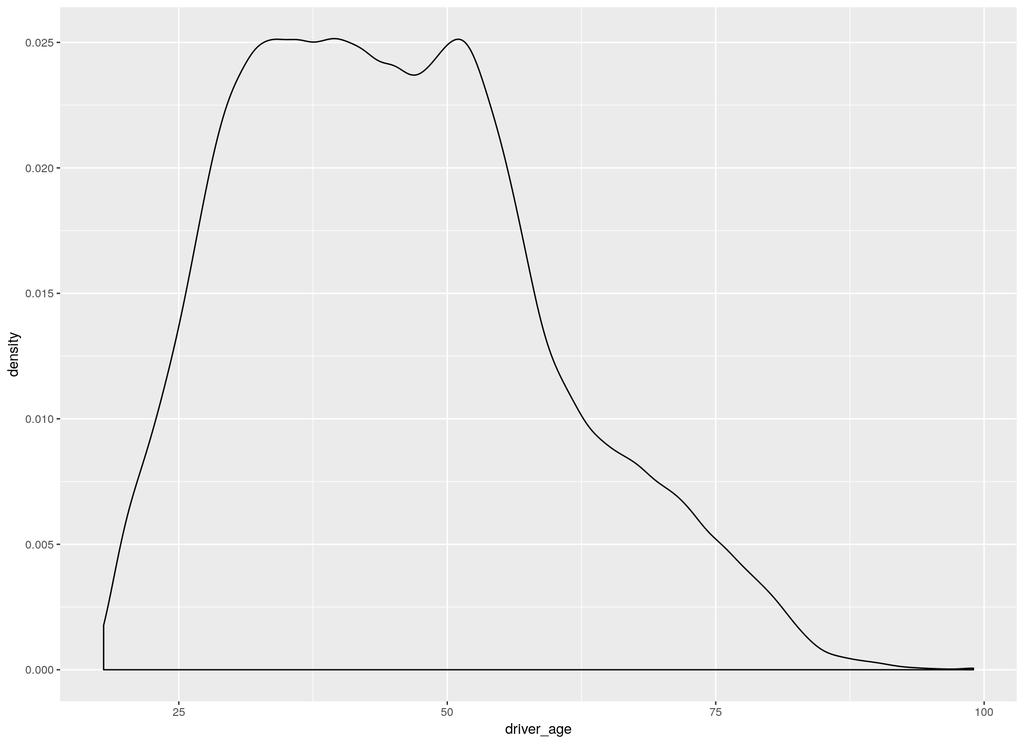

```r
ggplot(policyclaim_dt) +
    geom_density(aes(x = driver_age))
```

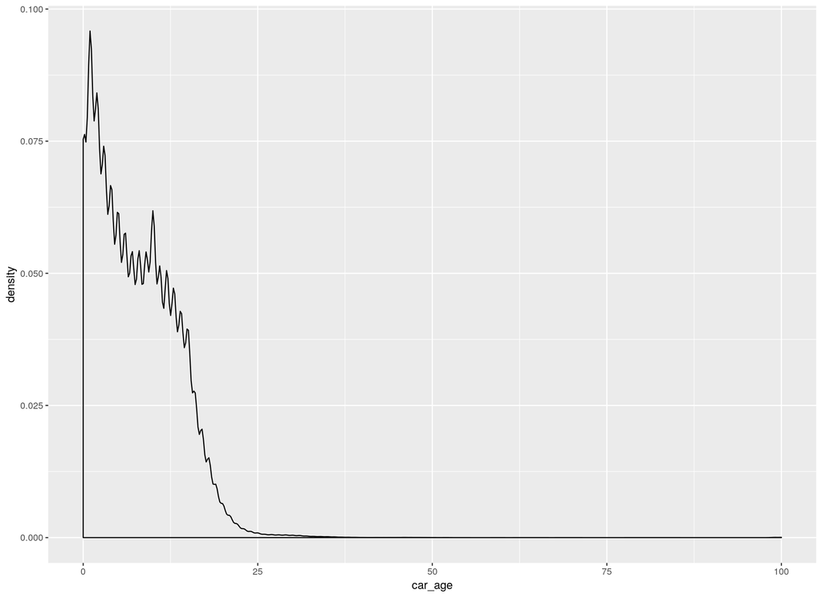

```r
ggplot(policyclaim_dt) +
    geom_density(aes(x = car_age))
```

For the purposes of discussion, how much data is lost were we to exclude drivers over the age of 75 and cars older than 20 years old?

```r
modeldata_dt <- policyclaim_dt %>%
    filter(driver_age <= 75, car_age <= 20)

glimpse(modeldata_dt)
```

```
## Observations: 395,068
## Variables: 17
## $ policy_id      <fct> 1, 2, 3, 4, 5, 6, 7, 8, 9, 10, 11, 12, 13, 14, 15, 16, 17, 18,...
## $ claim_count    <int> 0, 0, 0, 0, 0, 0, 0, 0, 0, 0, 0, 0, 0, 0, 0, 0, 0, 0, 0, 0, 0,...
## $ exposure       <dbl> 0.09, 0.84, 0.52, 0.45, 0.15, 0.75, 0.81, 0.05, 0.76, 0.34, 0....
## $ power          <fct> g, g, f, f, g, g, d, d, d, i, f, f, e, e, e, e, e, e, i, i, h,...
## $ car_age        <int> 0, 0, 2, 2, 0, 0, 1, 0, 9, 0, 2, 2, 0, 0, 0, 0, 0, 0, 0, 0, 0,...
## $ driver_age     <int> 46, 46, 38, 38, 41, 41, 27, 27, 23, 44, 32, 32, 33, 33, 33, 54...
## $ brand          <fct> Japanese (except Nissan) or Korean, Japanese (except Nissan) o...
## $ fuel           <fct> Diesel, Diesel, Regular, Regular, Diesel, Diesel, Regular, Reg...
## $ region         <fct> Aquitaine, Aquitaine, Nord-Pas-de-Calais, Nord-Pas-de-Calais, ...
## $ density        <int> 76, 76, 3003, 3003, 60, 60, 695, 695, 7887, 27000, 23, 23, 174...
## $ total_claims   <dbl> 0, 0, 0, 0, 0, 0, 0, 0, 0, 0, 0, 0, 0, 0, 0, 0, 0, 0, 0, 0, 0,...
## $ cat_driver_age <chr> "(42,74]", "(42,74]", "(26,42]", "(26,42]", "(26,42]", "(26,42...
## $ cat_car_age    <chr> "[0,1]", "[0,1]", "(1,4]", "(1,4]", "[0,1]", "[0,1]", "[0,1]",...
## $ cat_density    <chr> "(40,200]", "(40,200]", "(500,4.5e+03]", "(500,4.5e+03]", "(40...
## $ agg_power      <chr> "4", "4", "3", "3", "4", "4", "1", "1", "1", "other", "3", "3"...
## $ agg_power_2    <chr> "4", "4", "3", "3", "4", "4", "1", "1", "1", "6", "3", "3", "2...
## $ agg_region     <int> 1, 1, 8, 8, 9, 9, 1, 1, 8, 6, 4, 4, 6, 6, 6, 8, 6, 6, 6, 6, 6,...
```

Filtering for these values trims about 20,000 policies from the dataset, but we still have almost 400,000 policies to work with, so we will start here.

## 1.1 Split Data

We first split the data with the standard train/test methodology, but with a slight shift in focus: we use our models to price the test set, and then check it against the claims we received.

This leaves an open question for how we move on to simulating claims, but we tackle that issues later. First we need to focus on the data split.

We want a reasonable size book of policies to price, and we choose a book of 100,000 policies in our ‘test’ set. The rest of the model data will be used for training and model building. We could use cross-validation to build these models, but we will not. Instead I will create a smaller ‘validation’ set from the training data so we can quickly look at different models.

```r
testpolicies_dt <- modeldata_dt %>%
    sample_n(size = 100000, replace = FALSE)

train_dt <- modeldata_dt %>%
    filter(!policy_id %in% testpolicies_dt$policy_id)

glimpse(testpolicies_dt)
```

```
## Observations: 100,000
## Variables: 17
## $ policy_id      <fct> 322599, 2598, 139106, 280941, 271277, 317005, 309560, 384459, ...
## $ claim_count    <int> 0, 0, 0, 0, 0, 0, 0, 0, 0, 0, 0, 1, 0, 0, 0, 0, 0, 0, 0, 0, 0,...
## $ exposure       <dbl> 1.00, 0.53, 0.04, 0.28, 0.11, 0.26, 0.12, 0.64, 0.87, 0.42, 0....
## $ power          <fct> e, e, d, f, h, d, h, d, e, d, e, e, d, e, e, g, j, g, e, g, d,...
## $ car_age        <int> 3, 1, 3, 6, 1, 4, 8, 15, 4, 18, 6, 6, 13, 4, 5, 5, 4, 4, 6, 14...
## $ driver_age     <int> 71, 52, 50, 45, 56, 26, 31, 41, 54, 26, 38, 41, 37, 33, 46, 51...
## $ brand          <fct> Volkswagen, Audi, Skoda or Seat, Opel, General Motors or Ford,...
## $ fuel           <fct> Regular, Diesel, Regular, Diesel, Diesel, Regular, Regular, Re...
## $ region         <fct> Bretagne, Centre, Aquitaine, Centre, Nord-Pas-de-Calais, Ile-d...
## $ density        <int> 473, 1313, 280, 1313, 4024, 2007, 2498, 2642, 68, 153, 4327, 4...
## $ total_claims   <dbl> 0, 0, 0, 0, 0, 0, 0, 0, 0, 0, 0, 1755, 0, 0, 0, 0, 0, 0, 0, 0,...
## $ cat_driver_age <chr> "(42,74]", "(42,74]", "(42,74]", "(42,74]", "(42,74]", "(22,26...
## $ cat_car_age    <chr> "(1,4]", "[0,1]", "(1,4]", "(4,15]", "[0,1]", "(1,4]", "(4,15]...
## $ cat_density    <chr> "(200,500]", "(500,4.5e+03]", "(200,500]", "(500,4.5e+03]", "(...
## $ agg_power      <chr> "2", "2", "1", "3", "5", "1", "5", "1", "2", "1", "2", "2", "1...
## $ agg_power_2    <chr> "2", "2", "1", "3", "5", "1", "5", "1", "2", "1", "2", "2", "1...
## $ agg_region     <int> 3, 4, 1, 4, 8, 6, 1, 8, 10, 3, 6, 4, 4, 1, 4, 6, 5, 6, 6, 4, 5...
```

```r
glimpse(train_dt)
```

```
## Observations: 295,068
## Variables: 17
## $ policy_id      <fct> 1, 2, 4, 5, 6, 7, 8, 9, 10, 11, 12, 13, 15, 16, 17, 21, 22, 24...
## $ claim_count    <int> 0, 0, 0, 0, 0, 0, 0, 0, 0, 0, 0, 0, 0, 0, 0, 0, 0, 0, 0, 0, 0,...
## $ exposure       <dbl> 0.09, 0.84, 0.45, 0.15, 0.75, 0.81, 0.05, 0.76, 0.34, 0.10, 0....
## $ power          <fct> g, g, f, g, g, d, d, d, i, f, f, e, e, e, e, h, h, j, e, i, i,...
## $ car_age        <int> 0, 0, 2, 0, 0, 1, 0, 9, 0, 2, 2, 0, 0, 0, 0, 0, 0, 8, 0, 4, 4,...
## $ driver_age     <int> 46, 46, 38, 41, 41, 27, 27, 23, 44, 32, 32, 33, 33, 54, 69, 50...
## $ brand          <fct> Japanese (except Nissan) or Korean, Japanese (except Nissan) o...
## $ fuel           <fct> Diesel, Diesel, Regular, Diesel, Diesel, Regular, Regular, Reg...
## $ region         <fct> Aquitaine, Aquitaine, Nord-Pas-de-Calais, Pays-de-la-Loire, Pa...
## $ density        <int> 76, 76, 3003, 60, 60, 695, 695, 7887, 27000, 23, 23, 1746, 174...
## $ total_claims   <dbl> 0, 0, 0, 0, 0, 0, 0, 0, 0, 0, 0, 0, 0, 0, 0, 0, 0, 0, 0, 0, 0,...
## $ cat_driver_age <chr> "(42,74]", "(42,74]", "(26,42]", "(26,42]", "(26,42]", "(26,42...
## $ cat_car_age    <chr> "[0,1]", "[0,1]", "(1,4]", "[0,1]", "[0,1]", "[0,1]", "[0,1]",...
## $ cat_density    <chr> "(40,200]", "(40,200]", "(500,4.5e+03]", "(40,200]", "(40,200]...
## $ agg_power      <chr> "4", "4", "3", "4", "4", "1", "1", "1", "other", "3", "3", "2"...
## $ agg_power_2    <chr> "4", "4", "3", "4", "4", "1", "1", "1", "6", "3", "3", "2", "2...
## $ agg_region     <int> 1, 1, 8, 9, 9, 1, 1, 8, 6, 4, 4, 6, 6, 8, 6, 6, 6, 6, 8, 6, 6,...
```

```r
validpolicy_dt <- train_dt %>%
    sample_n(size = 50000, replace = FALSE)

trainpolicies_dt <- train_dt %>%
    filter(!policy_id %in% validpolicy_dt$policy_id)

glimpse(trainpolicies_dt)
```

```
## Observations: 245,068
## Variables: 17
## $ policy_id      <fct> 1, 2, 4, 5, 6, 8, 10, 13, 15, 16, 21, 24, 25, 26, 27, 29, 30, ...
## $ claim_count    <int> 0, 0, 0, 0, 0, 0, 0, 0, 0, 0, 0, 0, 0, 0, 0, 0, 0, 0, 0, 0, 0,...
## $ exposure       <dbl> 0.09, 0.84, 0.45, 0.15, 0.75, 0.05, 0.34, 0.55, 0.01, 0.87, 0....
## $ power          <fct> g, g, f, g, g, d, i, e, e, e, h, j, e, i, i, e, f, f, f, f, e,...
## $ car_age        <int> 0, 0, 2, 0, 0, 0, 0, 0, 0, 0, 0, 8, 0, 4, 4, 0, 0, 0, 0, 0, 8,...
## $ driver_age     <int> 46, 46, 38, 41, 41, 27, 44, 33, 33, 54, 50, 30, 73, 40, 40, 45...
## $ brand          <fct> Japanese (except Nissan) or Korean, Japanese (except Nissan) o...
## $ fuel           <fct> Diesel, Diesel, Regular, Diesel, Diesel, Regular, Regular, Reg...
## $ region         <fct> Aquitaine, Aquitaine, Nord-Pas-de-Calais, Pays-de-la-Loire, Pa...
## $ density        <int> 76, 76, 3003, 60, 60, 695, 27000, 1746, 1746, 781, 3545, 3661,...
## $ total_claims   <dbl> 0, 0, 0, 0, 0, 0, 0, 0, 0, 0, 0, 0, 0, 0, 0, 0, 0, 0, 0, 0, 0,...
## $ cat_driver_age <chr> "(42,74]", "(42,74]", "(26,42]", "(26,42]", "(26,42]", "(26,42...
## $ cat_car_age    <chr> "[0,1]", "[0,1]", "(1,4]", "[0,1]", "[0,1]", "[0,1]", "[0,1]",...
## $ cat_density    <chr> "(40,200]", "(40,200]", "(500,4.5e+03]", "(40,200]", "(40,200]...
## $ agg_power      <chr> "4", "4", "3", "4", "4", "1", "other", "2", "2", "2", "5", "7"...
## $ agg_power_2    <chr> "4", "4", "3", "4", "4", "1", "6", "2", "2", "2", "5", "7", "2...
## $ agg_region     <int> 1, 1, 8, 9, 9, 1, 6, 6, 6, 8, 6, 6, 8, 6, 6, 10, 6, 6, 6, 3, 6...
```

```r
glimpse(validpolicy_dt)
```

```
## Observations: 50,000
## Variables: 17
## $ policy_id      <fct> 298518, 407526, 181361, 384084, 341700, 243582, 116344, 64291,...
## $ claim_count    <int> 0, 0, 0, 0, 0, 0, 0, 0, 0, 0, 0, 0, 0, 0, 0, 0, 0, 0, 0, 0, 0,...
## $ exposure       <dbl> 0.08, 0.38, 0.06, 0.26, 0.95, 0.24, 1.00, 0.93, 0.82, 0.04, 1....
## $ power          <fct> f, g, f, f, f, e, g, f, g, j, k, f, f, g, g, h, d, f, e, g, h,...
## $ car_age        <int> 17, 1, 11, 1, 5, 3, 10, 0, 6, 4, 6, 12, 2, 0, 1, 5, 0, 3, 4, 1...
## $ driver_age     <int> 29, 63, 29, 58, 26, 58, 41, 63, 48, 46, 66, 73, 33, 40, 30, 53...
## $ brand          <fct> Renault, Nissan or Citroen, Japanese (except Nissan) or Korean...
## $ fuel           <fct> Regular, Diesel, Diesel, Regular, Diesel, Regular, Diesel, Die...
## $ region         <fct> Poitou-Charentes, Nord-Pas-de-Calais, Aquitaine, Ile-de-France...
## $ density        <int> 632, 2648, 280, 15703, 55, 158, 97, 146, 522, 2790, 18, 44, 10...
## $ total_claims   <dbl> 0, 0, 0, 0, 0, 0, 0, 0, 0, 0, 0, 0, 0, 0, 0, 0, 0, 0, 0, 0, 0,...
## $ cat_driver_age <chr> "(26,42]", "(42,74]", "(26,42]", "(42,74]", "(22,26]", "(42,74...
## $ cat_car_age    <chr> "(15,Inf]", "[0,1]", "(4,15]", "[0,1]", "(4,15]", "(1,4]", "(4...
## $ cat_density    <chr> "(500,4.5e+03]", "(500,4.5e+03]", "(200,500]", "(4.5e+03,Inf]"...
## $ agg_power      <chr> "3", "4", "3", "3", "3", "2", "4", "3", "4", "7", "other", "3"...
## $ agg_power_2    <chr> "3", "4", "3", "3", "3", "2", "4", "3", "4", "7", "other", "3"...
## $ agg_region     <int> 10, 8, 1, 6, 3, 3, 9, 2, 9, 6, 4, 4, 4, 4, 2, 4, 8, 1, 4, 4, 3...
```

We ignore the test set for the moment, focusing solely on the training data. As always, we will start with simple models and see how they do, then look to add more complexity to our modelling and model assessment when further iterating on the model.

Also, we have avoided performing any kind of stratified sampling when splitting our data, which may prove to be an issue later. It is hoped that the use of aggregated categorical variables will help to mitigate this.

We want to split out the claim size data here so that we model the claim size data in the same way.

```r
trainclaim_dt <- claimdata_dt %>%
    filter(claim_amount <= largeloss_threshold) %>%
    filter(policy_id %in% trainpolicies_dt$policy_id)

validclaim_dt <- claimdata_dt %>%
    filter(claim_amount <= largeloss_threshold) %>%
    filter(policy_id %in% validpolicy_dt$policy_id)

testclaim_dt <- claimdata_dt %>%
    filter(claim_amount <= largeloss_threshold) %>%
    filter(policy_id %in% testpolicies_dt$policy_id)
```

Due to the very random nature of the claim sizes, the data split may not hugely relevant, but we may as well do it here now.

# 2 A First Pass at Pricing

Our initial approach to pricing is to split the premium charged in two: we look to model expected, everyday losses using a combination of GLMs: a Poisson model for the claims rate and a Gamma distribution for the claim amount. The product of these two is the risk premium for expected, operational losses.

We must also account for large tail losses. Modelling this using some power law distributions, we calculate an across-the-book charge for these events and see how we do on that. This second component is likely to be hard to properly estimate: it is likely a first pass will be to come with a rough heuristic for the amount to charge to cover infrequent but large losses.

Finally, we are ignoring fraud in this model. Arguably one of the most important parts of the business, our data lacks any data on fraud so we are perhaps best avoiding it. Should we have data, we would add a third component to our price to account and compensate for fraud.

## 2.1 Modeling Per-Policy Claim Rates

We return to the issue of modelling the claim rates. We will build our models with the training data, use simulation to assess the fit of the model with our training data, and then compare it to the validation set.

We first try an ‘intercept-only’ model, one with no predictors at all.

```r
claim_model_01 <- glm(claim_count ~ 1
                     ,offset = log(exposure)
                     ,family = poisson
                     ,data   = trainpolicies_dt)

summary(claim_model_01)
```

```
##
## Call:
## glm(formula = claim_count ~ 1, family = poisson, data = trainpolicies_dt,
##     offset = log(exposure))
##
## Deviance Residuals:
##     Min       1Q   Median       3Q      Max
## -0.5331  -0.3779  -0.2645  -0.1464   6.5299
##
## Coefficients:
##             Estimate Std. Error z value Pr(>|z|)
## (Intercept) -2.63934    0.01016  -259.7   <2e-16 ***
## ---
## Signif. codes:  0 '***' 0.001 '**' 0.01 '*' 0.05 '.' 0.1 ' ' 1
##
## (Dispersion parameter for poisson family taken to be 1)
##
##     Null deviance: 62920  on 245067  degrees of freedom
## Residual deviance: 62920  on 245067  degrees of freedom
## AIC: 81629
##
## Number of Fisher Scoring iterations: 6
```

```r
exp(coef(claim_model_01))
```

```
## (Intercept)
##  0.07140818
```

The overall claim rate for the training dataset is about 0.07 claims per policy per year, matching what we see in the data:

```r
trainpolicies_dt %>%
    summarise(claim_rate = sum(claim_count) / sum(exposure))
```

```
##    claim_rate
## 1: 0.07140818
```

### 2.1.1 Adding `cat_driver_age`

Now we add `cat_driver_age` as we know this has an effect on claims.

```r
claim_model_02 <- glm(claim_count ~ cat_driver_age
                     ,offset = log(exposure)
                     ,family = poisson
                     ,data   = trainpolicies_dt)

summary(claim_model_02)
```

```
##
## Call:
## glm(formula = claim_count ~ cat_driver_age, family = poisson,
##     data = trainpolicies_dt, offset = log(exposure))
##
## Deviance Residuals:
##     Min       1Q   Median       3Q      Max
## -0.6282  -0.3635  -0.2611  -0.1477   6.5580
##
## Coefficients:
##                        Estimate Std. Error z value Pr(>|z|)
## (Intercept)            -1.62280    0.04230  -38.37  < 2e-16 ***
## cat_driver_age(22,26]  -0.60845    0.05830  -10.44  < 2e-16 ***
## cat_driver_age(26,42]  -1.06255    0.04565  -23.28  < 2e-16 ***
## cat_driver_age(42,74]  -1.09451    0.04458  -24.55  < 2e-16 ***
## cat_driver_age(74,Inf] -0.96788    0.12521   -7.73 1.08e-14 ***
## ---
## Signif. codes:  0 '***' 0.001 '**' 0.01 '*' 0.05 '.' 0.1 ' ' 1
##
## (Dispersion parameter for poisson family taken to be 1)
##
##     Null deviance: 62920  on 245067  degrees of freedom
## Residual deviance: 62367  on 245063  degrees of freedom
## AIC: 81084
##
## Number of Fisher Scoring iterations: 6
```

So far, so good. `cat_driver_age` is certainly worth including in the model.

### 2.1.2 Adding `fuel`

We now add the `fuel` variable to the model.

```r
claim_model_03 <- glm(claim_count ~ cat_driver_age + fuel
                     ,offset = log(exposure)
                     ,family = poisson
                     ,data   = trainpolicies_dt)

summary(claim_model_03)
```

```
##
## Call:
## glm(formula = claim_count ~ cat_driver_age + fuel, family = poisson,
##     data = trainpolicies_dt, offset = log(exposure))
##
## Deviance Residuals:
##     Min       1Q   Median       3Q      Max
## -0.6565  -0.3504  -0.2637  -0.1477   6.6069
##
## Coefficients:
##                        Estimate Std. Error z value Pr(>|z|)
## (Intercept)            -1.53475    0.04399 -34.892  < 2e-16 ***
## cat_driver_age(22,26]  -0.62472    0.05835 -10.707  < 2e-16 ***
## cat_driver_age(26,42]  -1.08639    0.04577 -23.734  < 2e-16 ***
## cat_driver_age(42,74]  -1.11113    0.04464 -24.890  < 2e-16 ***
## cat_driver_age(74,Inf] -0.95642    0.12522  -7.638 2.21e-14 ***
## fuelRegular            -0.14481    0.02045  -7.082 1.42e-12 ***
## ---
## Signif. codes:  0 '***' 0.001 '**' 0.01 '*' 0.05 '.' 0.1 ' ' 1
##
## (Dispersion parameter for poisson family taken to be 1)
##
##     Null deviance: 62920  on 245067  degrees of freedom
## Residual deviance: 62317  on 245062  degrees of freedom
## AIC: 81036
##
## Number of Fisher Scoring iterations: 6
```

### 2.1.3 Adding `cat_car_age`

Car age may not have much effect, but it is worth trying, so we add `cat_car_age`.

```r
claim_model_04 <- glm(claim_count ~ cat_driver_age + fuel + cat_car_age
                     ,offset = log(exposure)
                     ,family = poisson
                     ,data   = trainpolicies_dt)

summary(claim_model_04)
```

```
##
## Call:
## glm(formula = claim_count ~ cat_driver_age + fuel + cat_car_age,
##     family = poisson, data = trainpolicies_dt, offset = log(exposure))
##
## Deviance Residuals:
##     Min       1Q   Median       3Q      Max
## -0.6678  -0.3535  -0.2635  -0.1478   6.5938
##
## Coefficients:
##                        Estimate Std. Error z value Pr(>|z|)
## (Intercept)            -1.50081    0.04897 -30.645  < 2e-16 ***
## cat_driver_age(22,26]  -0.63459    0.05842 -10.862  < 2e-16 ***
## cat_driver_age(26,42]  -1.09371    0.04587 -23.845  < 2e-16 ***
## cat_driver_age(42,74]  -1.11888    0.04481 -24.972  < 2e-16 ***
## cat_driver_age(74,Inf] -0.96860    0.12530  -7.730 1.07e-14 ***
## fuelRegular            -0.13086    0.02058  -6.358 2.05e-10 ***
## cat_car_age(15,Inf]    -0.24872    0.04646  -5.353 8.65e-08 ***
## cat_car_age(4,15]      -0.02249    0.02564  -0.877    0.380
## cat_car_age[0,1]       -0.01882    0.03671  -0.513    0.608
## ---
## Signif. codes:  0 '***' 0.001 '**' 0.01 '*' 0.05 '.' 0.1 ' ' 1
##
## (Dispersion parameter for poisson family taken to be 1)
##
##     Null deviance: 62920  on 245067  degrees of freedom
## Residual deviance: 62284  on 245059  degrees of freedom
## AIC: 81009
##
## Number of Fisher Scoring iterations: 6
```

Before we seek to add new parameters, we stop and see what model we have at the moment.

It is worth noting that all the coefficients we have fit for the model are negative, meaning that the baseline policy has the highest claim rate and other types of policies are less risky (a negative co-efficient reduces the incidence rate predicted by the model).

We should look at this now before we continue, ensuring that what we are doing makes some kind of sense to our intuition. Our intuition could be misleading, but it is worth checking all the same.

We create some fake policy data and then use the model to predict the claim rates.

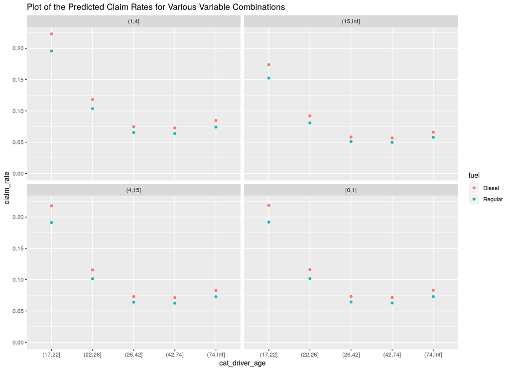

```r
cda_vals <- unique(trainpolicies_dt$cat_driver_age)
f_vals   <- unique(trainpolicies_dt$fuel)
cca_vals <- unique(trainpolicies_dt$cat_car_age)

newdata_1_dt <- CJ(cat_driver_age = cda_vals
                  ,fuel           = f_vals
                  ,cat_car_age    = cca_vals
                  ,exposure       = 1
                  )

testdata_claimrates <- predict(claim_model_04
                              ,newdata = newdata_1_dt
                              ,type = 'response')

newdata_1_dt[, claim_rate := testdata_claimrates]

ggplot(newdata_1_dt) +
    geom_point(aes(x = cat_driver_age, y = claim_rate, colour = fuel)) +
    facet_wrap(~cat_car_age) +
    expand_limits(y = 0) +
    ggtitle("Plot of the Predicted Claim Rates for Various Variable Combinations")
```

The plot illustrates a fact we had not commented on so far as the author had not noticed it: age has very little effect on the incidence rate of claims beyond the age of 26. This is confirmed from the model summary, the coefficient for `cat_driver_age` for the three levels from age 26 up are very close.

In relative terms, young drivers pose a lot of risk: drivers between the ages of 17-22 have a claim rate that is between 3-4 times that of older drivers. If this model is in any way a reasonable representation of reality - something we yet to verify - it is little wonder young drivers pay so much for car insurance!

### 2.1.4 Adding `cat_density`

The population density of a region could have an effect on claim incidence - if more people are around, the likelihood of an accident is higher as there are more drivers to crash into.

Lacking any intuition for how density may affect the claim rate, we again use the categorical version we created `cat_density`.

```r
claim_model_05 <- glm(claim_count ~ cat_driver_age + fuel + cat_car_age +
                                    cat_density
                     ,offset = log(exposure)
                     ,family = poisson
                     ,data   = trainpolicies_dt)

summary(claim_model_05)
```

```
##
## Call:
## glm(formula = claim_count ~ cat_driver_age + fuel + cat_car_age +
##     cat_density, family = poisson, data = trainpolicies_dt, offset = log(exposure))
##
## Deviance Residuals:
##     Min       1Q   Median       3Q      Max
## -0.7933  -0.3368  -0.2648  -0.1468   6.5529
##
## Coefficients:
##                          Estimate Std. Error z value Pr(>|z|)
## (Intercept)              -1.49357    0.05421 -27.550  < 2e-16 ***
## cat_driver_age(22,26]    -0.65673    0.05845 -11.235  < 2e-16 ***
## cat_driver_age(26,42]    -1.10318    0.04592 -24.024  < 2e-16 ***
## cat_driver_age(42,74]    -1.10850    0.04485 -24.717  < 2e-16 ***
## cat_driver_age(74,Inf]   -0.91486    0.12535  -7.298 2.91e-13 ***
## fuelRegular              -0.19285    0.02086  -9.247  < 2e-16 ***
## cat_car_age(15,Inf]      -0.17626    0.04664  -3.779 0.000157 ***
## cat_car_age(4,15]         0.01944    0.02577   0.754 0.450759
## cat_car_age[0,1]         -0.06253    0.03684  -1.697 0.089614 .
## cat_density(4.5e+03,Inf]  0.31783    0.04312   7.370 1.70e-13 ***
## cat_density(40,200]      -0.13212    0.03201  -4.128 3.66e-05 ***
## cat_density(500,4.5e+03]  0.17521    0.03077   5.693 1.25e-08 ***
## cat_density[0,40]        -0.31322    0.03835  -8.168 3.14e-16 ***
## ---
## Signif. codes:  0 '***' 0.001 '**' 0.01 '*' 0.05 '.' 0.1 ' ' 1
##
## (Dispersion parameter for poisson family taken to be 1)
##
##     Null deviance: 62920  on 245067  degrees of freedom
## Residual deviance: 61943  on 245055  degrees of freedom
## AIC: 80676
##
## Number of Fisher Scoring iterations: 6
```

Some careful inspection of the parameters also shows that the addition of a density variable changes the pattern previously observed: the coefficients of the model are no longer all negative, and we now have positive coefficients for levels of `cat_car_age`!

This will happen when modelling non-independent variables in a dataset.

Looking at the coefficients for `cat_density` we see that the larger population densities have a much larger claim rate, matching our intuition that living in areas with higher population density increases the chances of a claim.

Again, we will create some fake data and calculate the claim rates according to our model and visualise the results.

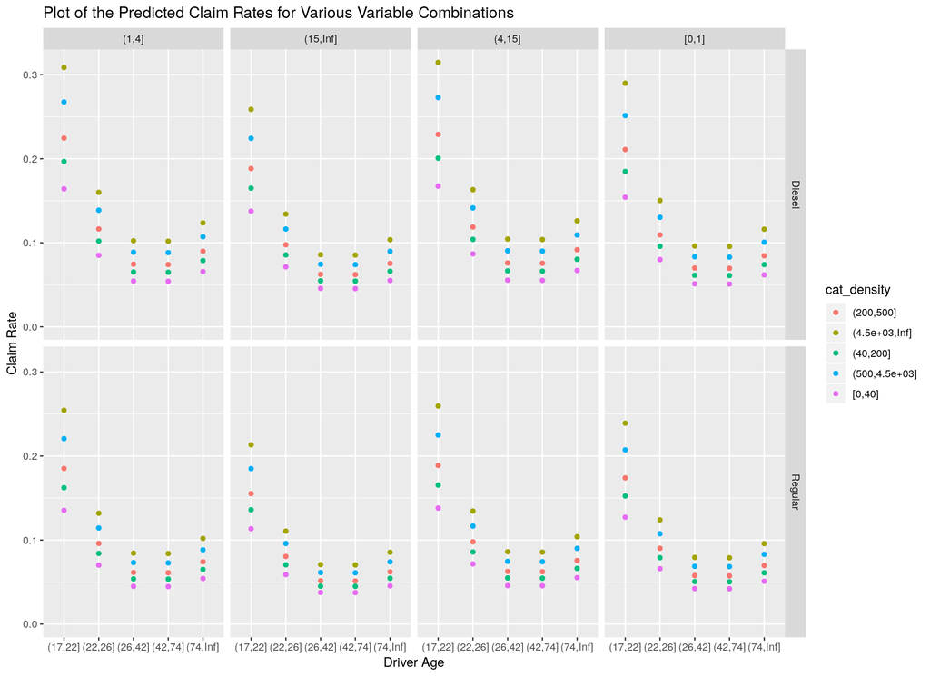

```r
cda_vals <- unique(trainpolicies_dt$cat_driver_age)
f_vals   <- unique(trainpolicies_dt$fuel)
cca_vals <- unique(trainpolicies_dt$cat_car_age)
d_vals   <- unique(trainpolicies_dt$cat_density)

newdata_2_dt <- CJ(cat_driver_age = cda_vals
                  ,fuel           = f_vals
                  ,cat_car_age    = cca_vals
                  ,cat_density    = d_vals
                  ,exposure       = 1
                  )

testdata_claimrates <- predict(claim_model_05
                              ,newdata = newdata_2_dt
                              ,type = 'response')

newdata_2_dt[, model_label := 'claim_model_05']
newdata_2_dt[, claim_rate  := testdata_claimrates]

ggplot(newdata_2_dt) +
    geom_point(aes(x = cat_driver_age, y = claim_rate, colour = cat_density)) +
    facet_grid(fuel ~ cat_car_age) +
    expand_limits(y = 0) +
    xlab("Driver Age") +
    ylab("Claim Rate") +
    ggtitle("Plot of the Predicted Claim Rates for Various Variable Combinations")
```

It is surprising to see the effect of the fuel-type of the car on the claim rate in this model. The incidence rate for a 17-22 year old in a densely populated area (`cat_density` = 4500-Inf) with a Diesel car is almost 0.3, as opposed to just under 0.25 for a Regular car. This may not sound like much, but the claim rate is 20% higher on a relative basis!

This is a curious result, and is perhaps an indication of a problem with the model?

We make a note of it for now and will return to the issue later.

### 2.1.5 Adding Interactions

At this point we have added most of the categorical variables we believe to be relevant (we are not adding region for the moment, but may look to add this later).

We currently do not look at the interaction of variables at all - each variable adds its own contribution to the estimation of the claim rate without regard to any other values, so it is worth adding some interactions and seeing if they have an effect.

So which interactions should we add?

A quick rule of thumb is that variables with large primary effects often have important interaction effects as well, so we first investigate the interaction of driver age and population density.

```r
claim_model_06 <- glm(claim_count ~ cat_driver_age + fuel + cat_car_age +
                                    cat_density + cat_driver_age:cat_density
                     ,offset = log(exposure)
                     ,family = poisson
                     ,data   = trainpolicies_dt)

summary(claim_model_06)
```

```
##
## Call:
## glm(formula = claim_count ~ cat_driver_age + fuel + cat_car_age +
##     cat_density + cat_driver_age:cat_density, family = poisson,
##     data = trainpolicies_dt, offset = log(exposure))
##
## Deviance Residuals:
##     Min       1Q   Median       3Q      Max
## -0.7279  -0.3373  -0.2646  -0.1465   6.5422
##
## Coefficients:
##                                                  Estimate Std. Error z value Pr(>|z|)
## (Intercept)                                     -1.519653   0.107113 -14.187  < 2e-16 ***
## cat_driver_age(22,26]                           -0.681298   0.149169  -4.567 4.94e-06 ***
## cat_driver_age(26,42]                           -1.015795   0.112985  -8.991  < 2e-16 ***
## cat_driver_age(42,74]                           -1.113396   0.110027 -10.119  < 2e-16 ***
## cat_driver_age(74,Inf]                          -0.949210   0.296370  -3.203 0.001361 **
## fuelRegular                                     -0.192595   0.020857  -9.234  < 2e-16 ***
## cat_car_age(15,Inf]                             -0.175162   0.046647  -3.755 0.000173 ***
## cat_car_age(4,15]                                0.020978   0.025784   0.814 0.415881
## cat_car_age[0,1]                                -0.061584   0.036843  -1.672 0.094618 .
## cat_density(4.5e+03,Inf]                         0.144367   0.264077   0.547 0.584595
## cat_density(40,200]                             -0.047953   0.129567  -0.370 0.711310
## cat_density(500,4.5e+03]                         0.170419   0.124419   1.370 0.170775
## cat_density[0,40]                               -0.244800   0.162779  -1.504 0.132613
## cat_driver_age(22,26]:cat_density(4.5e+03,Inf]   0.029870   0.322166   0.093 0.926128
## cat_driver_age(26,42]:cat_density(4.5e+03,Inf]   0.130230   0.272831   0.477 0.633127
## cat_driver_age(42,74]:cat_density(4.5e+03,Inf]   0.209657   0.270477   0.775 0.438258
## cat_driver_age(74,Inf]:cat_density(4.5e+03,Inf]  0.853670   0.521194   1.638 0.101440
## cat_driver_age(22,26]:cat_density(40,200]       -0.043724   0.187598  -0.233 0.815705
## cat_driver_age(26,42]:cat_density(40,200]       -0.183676   0.140677  -1.306 0.191671
## cat_driver_age(42,74]:cat_density(40,200]       -0.039425   0.136762  -0.288 0.773134
## cat_driver_age(74,Inf]:cat_density(40,200]       0.122829   0.363558   0.338 0.735475
## cat_driver_age(22,26]:cat_density(500,4.5e+03]   0.083023   0.174732   0.475 0.634684
## cat_driver_age(26,42]:cat_density(500,4.5e+03]  -0.040180   0.134765  -0.298 0.765589
## cat_driver_age(42,74]:cat_density(500,4.5e+03]   0.022981   0.131558   0.175 0.861327
## cat_driver_age(74,Inf]:cat_density(500,4.5e+03] -0.141513   0.393580  -0.360 0.719181
## cat_driver_age(22,26]:cat_density[0,40]          0.083182   0.225868   0.368 0.712666
## cat_driver_age(26,42]:cat_density[0,40]         -0.199466   0.176042  -1.133 0.257189
## cat_driver_age(42,74]:cat_density[0,40]         -0.009901   0.170743  -0.058 0.953759
## cat_driver_age(74,Inf]:cat_density[0,40]        -0.282501   0.463184  -0.610 0.541921
## ---
## Signif. codes:  0 '***' 0.001 '**' 0.01 '*' 0.05 '.' 0.1 ' ' 1
##
## (Dispersion parameter for poisson family taken to be 1)
##
##     Null deviance: 62920  on 245067  degrees of freedom
## Residual deviance: 61927  on 245039  degrees of freedom
## AIC: 80691
##
## Number of Fisher Scoring iterations: 6
```

A quick look at the various metrics for the model, not to mention the estimated coefficients themselves, reveals that little is added by this interaction so we drop it.

What about the interaction of driver age and fuel type?

```r
claim_model_07 <- glm(claim_count ~ cat_driver_age + fuel + cat_car_age +
                                    cat_density + cat_driver_age:fuel
                     ,offset = log(exposure)
                     ,family = poisson
                     ,data   = trainpolicies_dt)

summary(claim_model_07)
```

```
##
## Call:
## glm(formula = claim_count ~ cat_driver_age + fuel + cat_car_age +
##     cat_density + cat_driver_age:fuel, family = poisson, data = trainpolicies_dt,
##     offset = log(exposure))
##
## Deviance Residuals:
##     Min       1Q   Median       3Q      Max
## -0.7652  -0.3369  -0.2650  -0.1469   6.5523
##
## Coefficients:
##                                    Estimate Std. Error z value Pr(>|z|)
## (Intercept)                        -1.56620    0.07487 -20.918  < 2e-16 ***
## cat_driver_age(22,26]              -0.61088    0.08811  -6.933 4.12e-12 ***
## cat_driver_age(26,42]              -1.03087    0.07165 -14.387  < 2e-16 ***
## cat_driver_age(42,74]              -1.02488    0.07072 -14.491  < 2e-16 ***
## cat_driver_age(74,Inf]             -0.87324    0.21935  -3.981 6.86e-05 ***
## fuelRegular                        -0.07026    0.08690  -0.809  0.41877
## cat_car_age(15,Inf]                -0.17767    0.04665  -3.808  0.00014 ***
## cat_car_age(4,15]                   0.01925    0.02578   0.747  0.45523
## cat_car_age[0,1]                   -0.06314    0.03684  -1.714  0.08658 .
## cat_density(4.5e+03,Inf]            0.31852    0.04313   7.385 1.53e-13 ***
## cat_density(40,200]                -0.13266    0.03201  -4.145 3.40e-05 ***
## cat_density(500,4.5e+03]            0.17512    0.03078   5.690 1.27e-08 ***
## cat_density[0,40]                  -0.31414    0.03835  -8.191 2.60e-16 ***
## cat_driver_age(22,26]:fuelRegular  -0.06591    0.11825  -0.557  0.57729
## cat_driver_age(26,42]:fuelRegular  -0.12067    0.09352  -1.290  0.19691
## cat_driver_age(42,74]:fuelRegular  -0.14467    0.09130  -1.585  0.11307
## cat_driver_age(74,Inf]:fuelRegular -0.07585    0.26727  -0.284  0.77657
## ---
## Signif. codes:  0 '***' 0.001 '**' 0.01 '*' 0.05 '.' 0.1 ' ' 1
##
## (Dispersion parameter for poisson family taken to be 1)
##
##     Null deviance: 62920  on 245067  degrees of freedom
## Residual deviance: 61940  on 245051  degrees of freedom
## AIC: 80681
##
## Number of Fisher Scoring iterations: 6
```

This call is marginal. We see a small improvement in residual deviance and the AIC stays about the same. We may drop this interaction in the future but we keep it for the moment.

We also notice that car age is not having a big effect in the model, so what happens if we drop it?

```r
claim_model_08 <- glm(claim_count ~ cat_driver_age + fuel + cat_density +
                                    cat_driver_age:fuel
                     ,offset = log(exposure)
                     ,family = poisson
                     ,data   = trainpolicies_dt)

summary(claim_model_08)
```

```
##
## Call:
## glm(formula = claim_count ~ cat_driver_age + fuel + cat_density +
##     cat_driver_age:fuel, family = poisson, data = trainpolicies_dt,
##     offset = log(exposure))
##
## Deviance Residuals:
##     Min       1Q   Median       3Q      Max
## -0.7566  -0.3412  -0.2659  -0.1469   6.5208
##
## Coefficients:
##                                    Estimate Std. Error z value Pr(>|z|)
## (Intercept)                        -1.56209    0.07171 -21.783  < 2e-16 ***
## cat_driver_age(22,26]              -0.61562    0.08807  -6.990 2.74e-12 ***
## cat_driver_age(26,42]              -1.03707    0.07159 -14.486  < 2e-16 ***
## cat_driver_age(42,74]              -1.03367    0.07062 -14.637  < 2e-16 ***
## cat_driver_age(74,Inf]             -0.87881    0.21932  -4.007 6.15e-05 ***
## fuelRegular                        -0.08771    0.08681  -1.010    0.312
## cat_density(4.5e+03,Inf]            0.31122    0.04266   7.295 2.98e-13 ***
## cat_density(40,200]                -0.13338    0.03200  -4.168 3.08e-05 ***
## cat_density(500,4.5e+03]            0.17376    0.03075   5.651 1.60e-08 ***
## cat_density[0,40]                  -0.31595    0.03831  -8.248  < 2e-16 ***
## cat_driver_age(22,26]:fuelRegular  -0.05565    0.11823  -0.471    0.638
## cat_driver_age(26,42]:fuelRegular  -0.11134    0.09350  -1.191    0.234
## cat_driver_age(42,74]:fuelRegular  -0.13453    0.09128  -1.474    0.141
## cat_driver_age(74,Inf]:fuelRegular -0.06509    0.26725  -0.244    0.808
## ---
## Signif. codes:  0 '***' 0.001 '**' 0.01 '*' 0.05 '.' 0.1 ' ' 1
##
## (Dispersion parameter for poisson family taken to be 1)
##
##     Null deviance: 62920  on 245067  degrees of freedom
## Residual deviance: 61966  on 245054  degrees of freedom
## AIC: 80701
##
## Number of Fisher Scoring iterations: 6
```

Once again we have a marginal call, but I would be inclined to keep car age in. In fact, we will add an interaction between it and driver age.

```r
claim_model_09 <- glm(claim_count ~ cat_driver_age + fuel + cat_car_age +
                                    cat_density + cat_driver_age:fuel +
                                    cat_driver_age:cat_car_age
                     ,offset = log(exposure)
                     ,family = poisson
                     ,data   = trainpolicies_dt)

summary(claim_model_09)
```

```
##
## Call:
## glm(formula = claim_count ~ cat_driver_age + fuel + cat_car_age +
##     cat_density + cat_driver_age:fuel + cat_driver_age:cat_car_age,
##     family = poisson, data = trainpolicies_dt, offset = log(exposure))
##
## Deviance Residuals:
##     Min       1Q   Median       3Q      Max
## -0.7779  -0.3361  -0.2649  -0.1467   6.5256
##
## Coefficients:
##                                            Estimate Std. Error z value Pr(>|z|)
## (Intercept)                                -1.82532    0.15041 -12.135  < 2e-16 ***
## cat_driver_age(22,26]                      -0.49045    0.18218  -2.692  0.00710 **
## cat_driver_age(26,42]                      -0.73614    0.15379  -4.787 1.70e-06 ***
## cat_driver_age(42,74]                      -0.77044    0.15212  -5.065 4.09e-07 ***
## cat_driver_age(74,Inf]                     -0.20298    0.29309  -0.693  0.48860
## fuelRegular                                -0.08451    0.08798  -0.961  0.33679
## cat_car_age(15,Inf]                         0.15017    0.19744   0.761  0.44693
## cat_car_age(4,15]                           0.31407    0.14974   2.097  0.03595 *
## cat_car_age[0,1]                            0.23093    0.22434   1.029  0.30330
## cat_density(4.5e+03,Inf]                    0.31584    0.04315   7.320 2.48e-13 ***
## cat_density(40,200]                        -0.13212    0.03201  -4.127 3.68e-05 ***
## cat_density(500,4.5e+03]                    0.17515    0.03078   5.691 1.27e-08 ***
## cat_density[0,40]                          -0.31351    0.03836  -8.174 2.99e-16 ***
## cat_driver_age(22,26]:fuelRegular          -0.04517    0.11938  -0.378  0.70516
## cat_driver_age(26,42]:fuelRegular          -0.10799    0.09469  -1.140  0.25410
## cat_driver_age(42,74]:fuelRegular          -0.12920    0.09244  -1.398  0.16221
## cat_driver_age(74,Inf]:fuelRegular         -0.05672    0.26796  -0.212  0.83235
## cat_driver_age(22,26]:cat_car_age(15,Inf]  -0.57616    0.30781  -1.872  0.06123 .
## cat_driver_age(26,42]:cat_car_age(15,Inf]  -0.28355    0.21216  -1.336  0.18139
## cat_driver_age(42,74]:cat_car_age(15,Inf]  -0.35045    0.20763  -1.688  0.09143 .
## cat_driver_age(74,Inf]:cat_car_age(15,Inf] -1.06203    0.63828  -1.664  0.09613 .
## cat_driver_age(22,26]:cat_car_age(4,15]    -0.07320    0.18587  -0.394  0.69370
## cat_driver_age(26,42]:cat_car_age(4,15]    -0.35857    0.15580  -2.301  0.02137 *
## cat_driver_age(42,74]:cat_car_age(4,15]    -0.28394    0.15370  -1.847  0.06470 .
## cat_driver_age(74,Inf]:cat_car_age(4,15]   -0.92459    0.29532  -3.131  0.00174 **
## cat_driver_age(22,26]:cat_car_age[0,1]     -0.31194    0.27522  -1.133  0.25705
## cat_driver_age(26,42]:cat_car_age[0,1]     -0.28434    0.23272  -1.222  0.22177
## cat_driver_age(42,74]:cat_car_age[0,1]     -0.30025    0.22962  -1.308  0.19102
## cat_driver_age(74,Inf]:cat_car_age[0,1]    -0.81558    0.47725  -1.709  0.08747 .
## ---
## Signif. codes:  0 '***' 0.001 '**' 0.01 '*' 0.05 '.' 0.1 ' ' 1
##
## (Dispersion parameter for poisson family taken to be 1)
##
##     Null deviance: 62920  on 245067  degrees of freedom
## Residual deviance: 61914  on 245039  degrees of freedom
## AIC: 80678
##
## Number of Fisher Scoring iterations: 6
```

Going with the principle of parsimony (i.e. simple is best), we will remove this interaction.

We have tried a bunch of potentially interesting interactions but the only one we are keeping is the interaction between driver age and fuel type in the car: `claim_model_07` is the model variable containing the fit.

Before we move on, we repeat our previous visualisation of the outputs of the model we have built. We build table of data representing the different combinations of inputs and then look at the incidence rate.

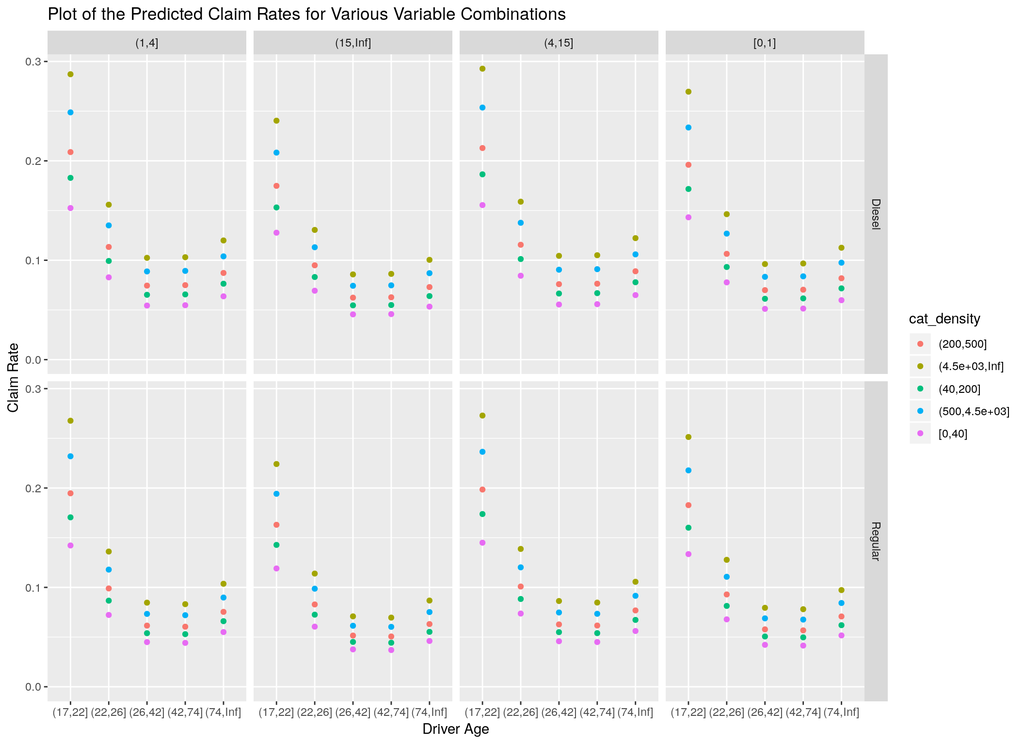

```r
cda_vals <- unique(trainpolicies_dt$cat_driver_age)
f_vals   <- unique(trainpolicies_dt$fuel)
cca_vals <- unique(trainpolicies_dt$cat_car_age)
d_vals   <- unique(trainpolicies_dt$cat_density)

newdata_3_dt <- CJ(cat_driver_age = cda_vals
                  ,fuel           = f_vals
                  ,cat_car_age    = cca_vals
                  ,cat_density    = d_vals
                  ,exposure       = 1
                  )

testdata_claimrates <- predict(claim_model_07
                              ,newdata = newdata_3_dt
                              ,type = 'response')

newdata_3_dt[, model_label := 'claim_model_07']
newdata_3_dt[, claim_rate  := testdata_claimrates]

ggplot(newdata_3_dt) +
    geom_point(aes(x = cat_driver_age, y = claim_rate, colour = cat_density)) +
    facet_grid(fuel ~ cat_car_age) +
    expand_limits(y = 0) +
    xlab("Driver Age") +
    ylab("Claim Rate") +
    ggtitle("Plot of the Predicted Claim Rates for Various Variable Combinations")
```

At a first glance, it appears that this model predicts a slightly lower claim rate than the previous one we used. To check this, we combine the two output data.tables and plot them at the same time.

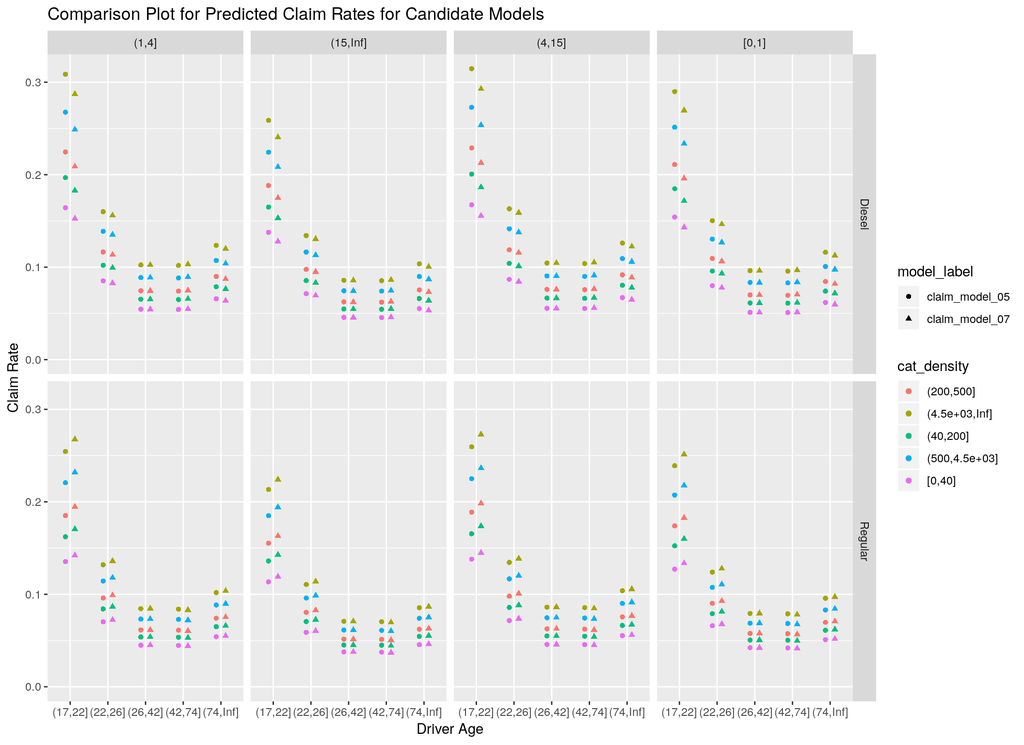

```r
ggplot(rbind(newdata_2_dt, newdata_3_dt)) +
    geom_point(aes(x = cat_driver_age, y = claim_rate, colour = cat_density
                  ,group = model_label, shape = model_label)
              ,position = position_dodge(width = 0.5)) +
    facet_grid(fuel ~ cat_car_age) +
    expand_limits(y = 0) +
    xlab("Driver Age") +
    ylab("Claim Rate") +
    ggtitle("Comparison Plot for Predicted Claim Rates for Candidate Models")
```

From this plot, we see that `claim_model_05` (without the interaction) gives slightly higher incidence rates for Diesel cars, but lower ones for Regular cars. This pattern is particularly pronounced for younger drivers.

# 3 Assessing the Claim Rate Models

We turn our attention to assessing the validity of our claim rate models. We also want our models to capture uncertainty as much as possible but for the moment that is secondary.

A first approach to this is to use MonteCarlo simulation to generate counts of claims, and then compare the total claim count to those observed in the data set.

One minor detail is that not all policies have equal exposure, and so we need to adjust the input to the Poisson process to account for this. As claim rates are based on time units of 1 year, this is a matter of multiplying the claim rate by the exposure.

## 3.1 Simulation Using Predicted Outputs

We first focus our model validation within the training set. We ignore the uncertainty in the model output and use the predictions of the claim rate as they are.

We will assess both `claim_model_05` and `claim_model_07` as our previous work showed little between them.

First we simulate claim counts from `claim_model_05` and see how the distribution of simulated claims matches what we observed.

```r
train_claimcount <- sum(trainpolicies_dt$claim_count)


claim_rate <- predict(claim_model_05, newdata = trainpolicies_dt
                     ,type = 'response')

sim_rates <- claim_rate * trainpolicies_dt$exposure


run_mc_sim <- function() {
    sapply(sim_rates, function(iter_rate) rpois(1, iter_rate))
}

sim_claimcount_05 <- replicate(n_sim, sum(run_mc_sim()))
```

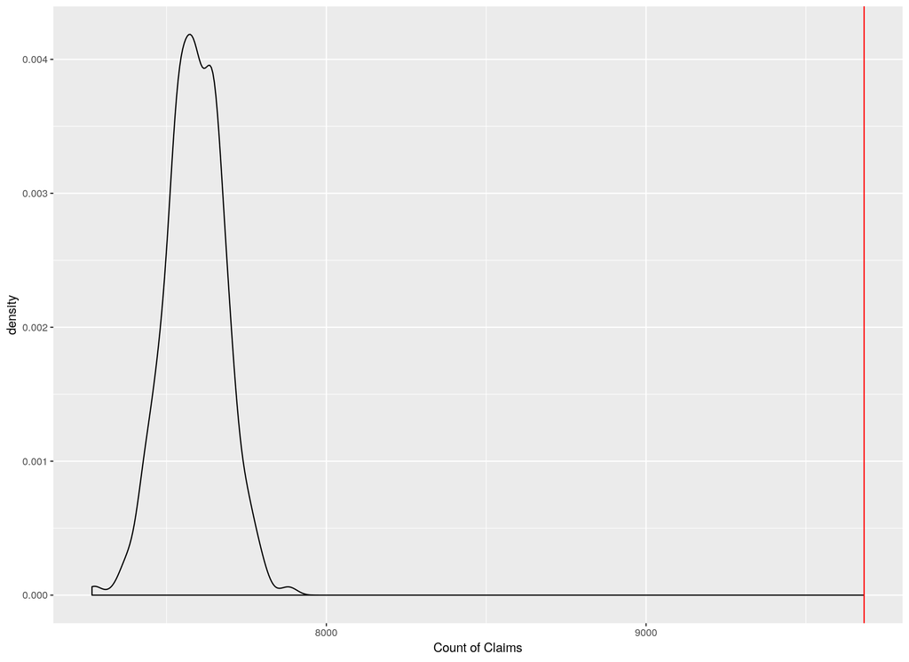

```r
ggplot() +
    geom_density(aes(x = sim_claimcount_05)) +
    geom_vline(aes(xintercept = train_claimcount), colour = 'red') +
    xlab("Count of Claims")
```

It appears our Poisson model is underesimating the claim rate significantly, and is also likely to have less variance than observed in reality.

What about `claim_model_07`?

```r
claim_rate <- predict(claim_model_07, newdata = trainpolicies_dt
                     ,type = 'response')

sim_rates <- claim_rate * trainpolicies_dt$exposure

run_mc_sim <- function() {
    sapply(sim_rates, function(iter_rate) rpois(1, iter_rate))
}

sim_claimcount_07 <- replicate(n_sim, sum(run_mc_sim()))
```

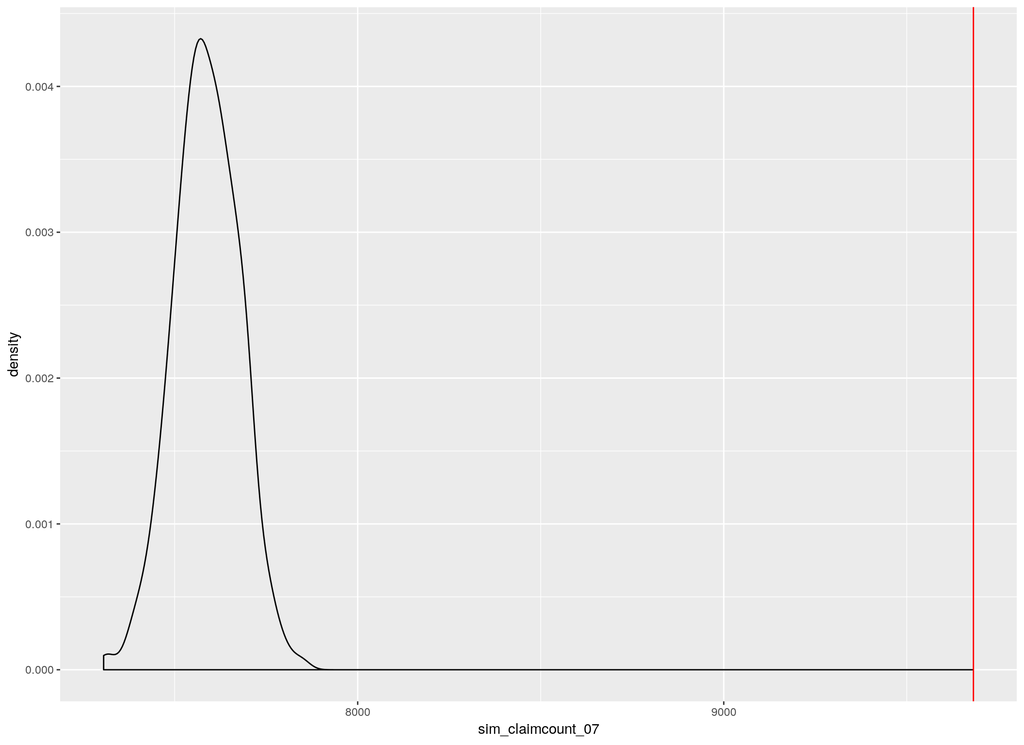

```r
ggplot() +
    geom_density(aes(x = sim_claimcount_07)) +
    geom_vline(aes(xintercept = train_claimcount), colour = 'red')
```

We see similar results for this second model. We likely need a variant of the Poisson process to account for the greater dispersion observed in the data.

Because it is fast to do and computationally cheap, we will check the validation set in a similar way. It is unlikely to be any better than the training set though and we will only run this for `claim_model_07` to save some time.

```r
valid_claimcount <- sum(validpolicy_dt$claim_count)


claim_rate <- predict(claim_model_07, newdata = validpolicy_dt
                     ,type = 'response')

sim_rates <- claim_rate * validpolicy_dt$exposure


run_mc_sim <- function() {
    sapply(sim_rates, function(iter_rate) rpois(1, iter_rate))
}

sim_claimcount_07 <- replicate(n_sim, sum(run_mc_sim()))
```

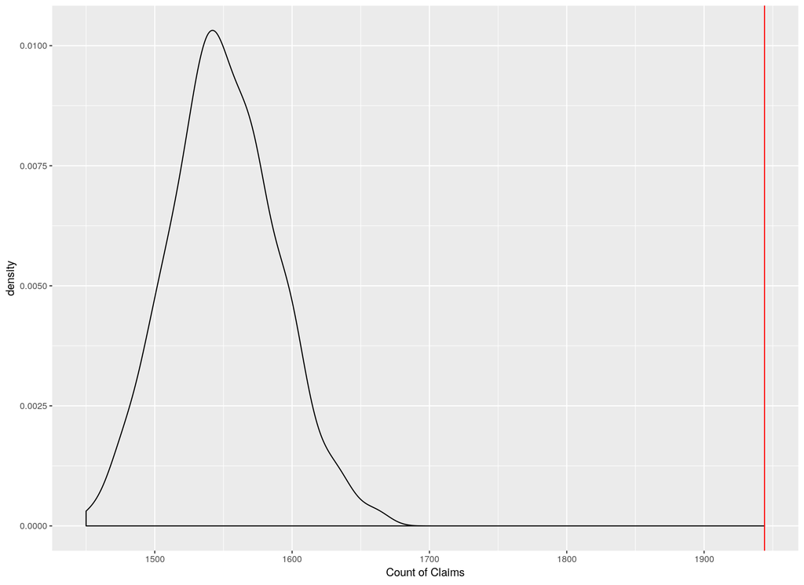

```r
ggplot() +
    geom_density(aes(x = sim_claimcount_07)) +
    geom_vline(aes(xintercept = valid_claimcount), colour = 'red') +
    xlab("Count of Claims")
```

## 3.2 Simulation Using Standard Errors for Parameters

We now incorporate the standard errors estimated from the GLM. For each MonteCarlo simulation we take the additional step of sampling from the model coefficients. We use this sample of coefficients to calculate an individual claim rate for each policy and then draw from this. Due to the nature of the assumptions in the model, this should not affect the expectations for claims, but we expect that the variance in the simulations will increase.

Performing these steps is a little more involved than before, but we can wrap this data in the creation of each MonteCarlo simulation.

```r
data_mat <- t(model.matrix(formula(claim_model_05), trainpolicies_dt))

run_mc_sim <- function() {
    model_coef <- coef(arm::sim(claim_model_05, n.sim = 2))[1,]

    output <- as.vector(model_coef %*% data_mat)

    sim_rates <- exp(output) * trainpolicies_dt$exposure

    sapply(sim_rates, function(iter_rate) rpois(1, iter_rate))
}

sim_claimcount_stderr_05 <- replicate(n_sim, sum(run_mc_sim()))
```

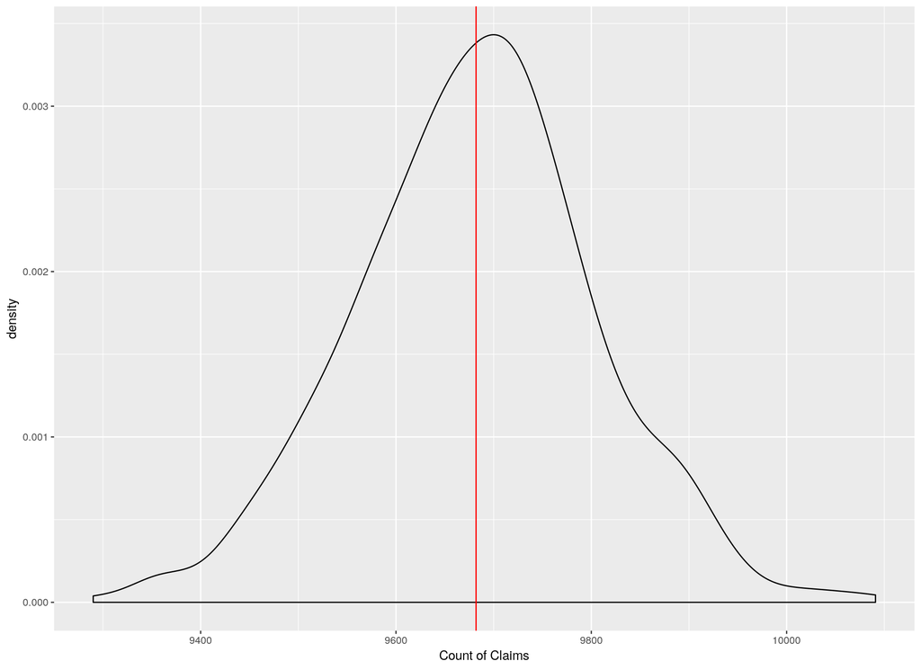

```r
ggplot() +
    geom_density(aes(x = sim_claimcount_stderr_05)) +
    geom_vline(aes(xintercept = train_claimcount), colour = 'red') +
    xlab("Count of Claims")
```

Adding the variation due to the standard error in the coefficient estimates seems to be doing a much better job! I am surprised by this, we might expect a wider distribution for the claims counts from the change we made, but at best it would manifest as the distribution of outcomes containing the observed count. In fact, this result is almost TOO good. It is such a huge improvement we are justified in being suspicious. We need to check our code for errors at this point.

Before that, we check `claim_model_07` using the sampled output of the model and repeat the count simulations.

```r
data_mat <- t(model.matrix(formula(claim_model_07), trainpolicies_dt))

run_mc_sim <- function() {
    model_coef <- coef(arm::sim(claim_model_07, n.sim = 2))[1,]

    output <- as.vector(model_coef %*% data_mat)

    sim_rates <- exp(output) * trainpolicies_dt$exposure

    sapply(sim_rates, function(iter_rate) rpois(1, iter_rate))
}

sim_claimcount_stderr_07 <- replicate(n_sim, sum(run_mc_sim()))
```

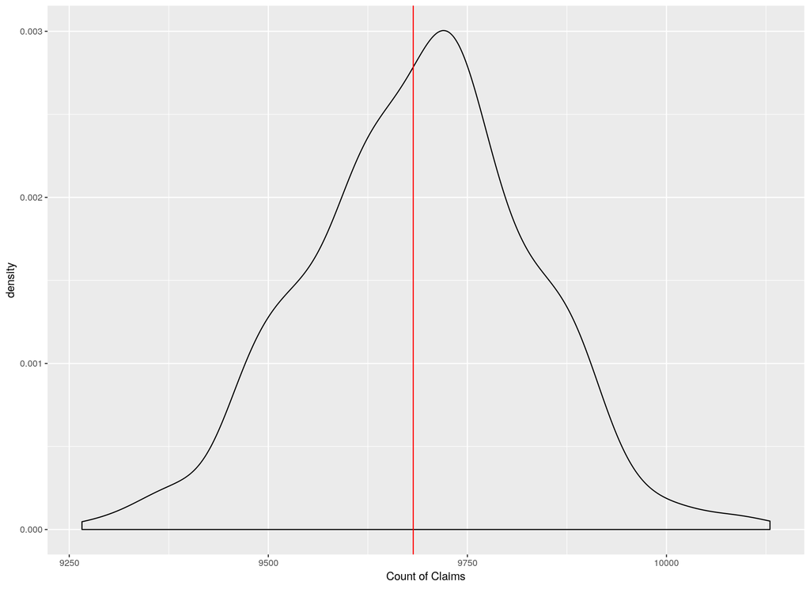

```r
ggplot() +
    geom_density(aes(x = sim_claimcount_stderr_07)) +
    geom_vline(aes(xintercept = train_claimcount), colour = 'red') +
    xlab("Count of Claims")
```

### 3.2.1 Simulating on the Validation Data

We need to look at the output of this approach using the validation data. Once again we will look at both models, as this is likely to be a good test of the performance of the two datasets.

```r
data_mat <- t(model.matrix(formula(claim_model_05), validpolicy_dt))

run_mc_sim <- function() {
    model_coef <- coef(arm::sim(claim_model_05, n.sim = 2))[1,]

    output <- as.vector(model_coef %*% data_mat)

    sim_rates <- exp(output) * validpolicy_dt$exposure

    sapply(sim_rates, function(iter_rate) rpois(1, iter_rate))
}

sim_claimcount_stderr_valid_05 <- replicate(n_sim, sum(run_mc_sim()))

data_mat <- t(model.matrix(formula(claim_model_07), validpolicy_dt))

run_mc_sim <- function() {
    model_coef <- coef(arm::sim(claim_model_07, n.sim = 2))[1,]

    output <- as.vector(model_coef %*% data_mat)

    sim_rates <- exp(output) * validpolicy_dt$exposure

    sapply(sim_rates, function(iter_rate) rpois(1, iter_rate))
}

sim_claimcount_stderr_valid_07 <- replicate(n_sim, sum(run_mc_sim()))
```

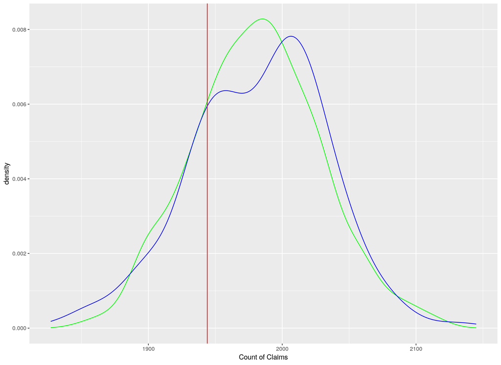

```r
ggplot() +
    stat_density(aes(x = sim_claimcount_stderr_valid_05)
                ,geom = 'line', colour = 'green') +
    stat_density(aes(x = sim_claimcount_stderr_valid_07)
                ,geom = 'line', colour = 'blue') +
    geom_vline(aes(xintercept = valid_claimcount), colour = 'red') +
    expand_limits(y = 0) +
    xlab("Count of Claims")
```

The above code involves a bit of copy-and-paste operations, especially for the creation of the function that calculates the value of the MonteCarlo iteration. It will be worth improving that and perhaps creating a more generic creator function to create those iteration calculations.

Having looked at both, I am inclined to go with using `claim_model_07` as it was slightly better and is only adding a single interaction. I am violating the parsimony principle here, which may be a mistake, but I will go for it for now.

# 4 Estimating Claim Sizes

As discussed previously, the size of the claim tends to be difficult to predict and is very noisy. That said, we are starting simple, so we fit a Gamma distribution and accept our predictions for claim amount may be on the low side. By taking expectations, our prices may be sound, we will have to check.

```r
size_model_01 <- glm(claim_amount ~ 1
                    ,family = Gamma(link = 'log')
                    ,data   = trainclaim_dt)

summary(size_model_01)
```

```
##
## Call:
## glm(formula = claim_amount ~ 1, family = Gamma(link = "log"),
##     data = trainclaim_dt)
##
## Deviance Residuals:
##     Min       1Q   Median       3Q      Max
## -3.2701  -0.5294   0.0086   0.0743   1.9510
##
## Coefficients:
##             Estimate Std. Error t value Pr(>|t|)
## (Intercept)  7.03808    0.00725   970.8   <2e-16 ***
## ---
## Signif. codes:  0 '***' 0.001 '**' 0.01 '*' 0.05 '.' 0.1 ' ' 1
##
## (Dispersion parameter for Gamma family taken to be 0.4877457)
##
##     Null deviance: 6077.3  on 9278  degrees of freedom
## Residual deviance: 6077.3  on 9278  degrees of freedom
## AIC: 147945
##
## Number of Fisher Scoring iterations: 5
```

Having now fit the model, we should first check how our predictions compare. Much like the previous workbook, our expectations for model performance are very low.

```r
predict(size_model_01, type = 'response')[1]
```

```
##        1
## 1139.193
```

```r
mean(trainclaim_dt$claim_amount)
```

```
## [1] 1139.193
```

With this ‘intercept-only’ model for the data, we are predict a claim of about EUR 1,100 for each claim which matches the average claim in the training dataset.

## 4.1 Adding `cat_driver_age`

As driver age was a major predictor for claim rate it would make sense if it also affects the size of the claim, so we try that first. Once again, we compare this model to the intercept-only model.

```r
size_model_02 <- glm(claim_amount ~ cat_driver_age
                    ,family = Gamma(link = 'log')
                    ,data   = trainclaim_dt)

summary(size_model_02)
```

```
##
## Call:
## glm(formula = claim_amount ~ cat_driver_age, family = Gamma(link = "log"),
##     data = trainclaim_dt)
##
## Deviance Residuals:
##     Min       1Q   Median       3Q      Max
## -3.2706  -0.5255   0.0091   0.0797   1.9876
##
## Coefficients:
##                        Estimate Std. Error t value Pr(>|t|)
## (Intercept)             7.11416    0.03078 231.139  < 2e-16 ***
## cat_driver_age(22,26]  -0.06251    0.04204  -1.487  0.13702
## cat_driver_age(26,42]  -0.09771    0.03312  -2.950  0.00318 **
## cat_driver_age(42,74]  -0.07422    0.03237  -2.293  0.02187 *
## cat_driver_age(74,Inf]  0.09080    0.09186   0.988  0.32295
## ---
## Signif. codes:  0 '***' 0.001 '**' 0.01 '*' 0.05 '.' 0.1 ' ' 1
##
## (Dispersion parameter for Gamma family taken to be 0.4869265)
##
##     Null deviance: 6077.3  on 9278  degrees of freedom
## Residual deviance: 6070.7  on 9274  degrees of freedom
## AIC: 147942
##
## Number of Fisher Scoring iterations: 5
```

The residual deviance has reduced from 6077 to 6070, a few points larger than the 4 we would expect from adding a categorical with 5 levels. The AIC improved marginally as well from 147945 to 147942.

Just as a quick check, we plot the predicted against the observed.

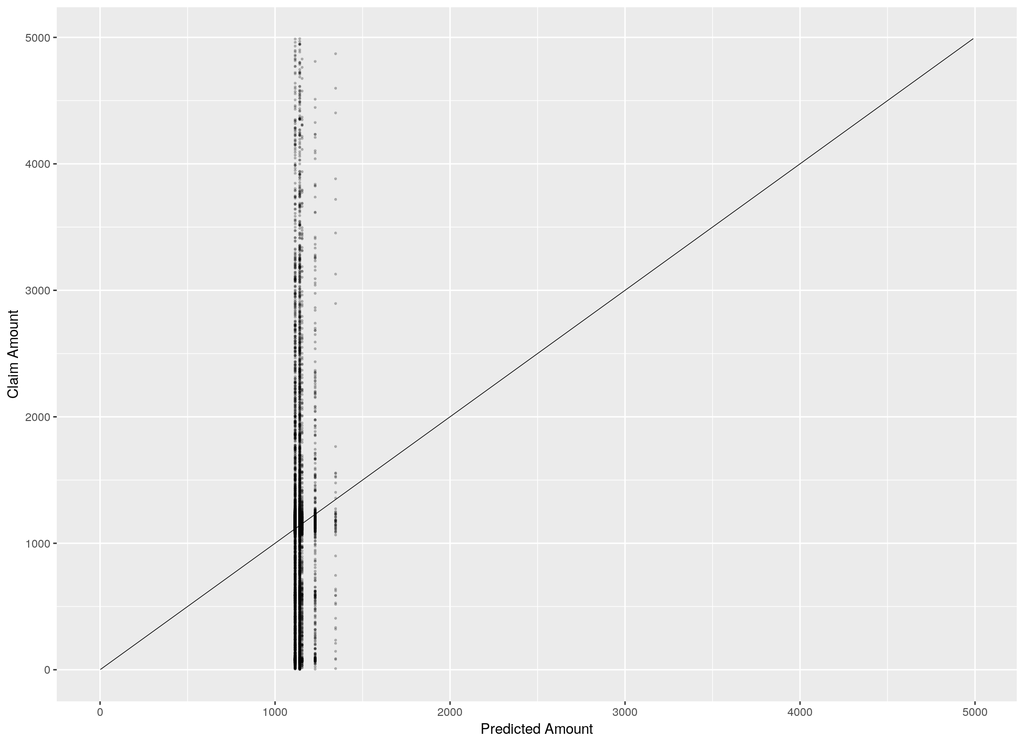

```r
ggplot(trainclaim_dt) +
    geom_line (aes(x = claim_amount, y = claim_amount), size = 0.25) +
    geom_point(aes(x = predict(size_model_02, type = 'response')
                  ,y = claim_amount), size = 0.4, alpha = 0.2) +
    expand_limits(y = 0) +
    xlab("Predicted Amount") +
    ylab("Claim Amount")
```

## 4.2 Adding `fuel`

Next we look at `fuel` as this also had an effect on the claim rate.

```r
size_model_03 <- glm(claim_amount ~ cat_driver_age + fuel
                    ,family = Gamma(link = 'log')
                    ,data   = trainclaim_dt)

summary(size_model_03)
```

```
##
## Call:
## glm(formula = claim_amount ~ cat_driver_age + fuel, family = Gamma(link = "log"),
##     data = trainclaim_dt)
##
## Deviance Residuals:
##     Min       1Q   Median       3Q      Max
## -3.2660  -0.5267   0.0078   0.0811   1.9842
##
## Coefficients:
##                        Estimate Std. Error t value Pr(>|t|)
## (Intercept)             7.13140    0.03201 222.769  < 2e-16 ***
## cat_driver_age(22,26]  -0.06620    0.04205  -1.574  0.11547
## cat_driver_age(26,42]  -0.10295    0.03321  -3.100  0.00194 **
## cat_driver_age(42,74]  -0.07814    0.03241  -2.411  0.01594 *
## cat_driver_age(74,Inf]  0.09334    0.09183   1.016  0.30944
## fuelRegular            -0.02846    0.01458  -1.952  0.05097 .
## ---
## Signif. codes:  0 '***' 0.001 '**' 0.01 '*' 0.05 '.' 0.1 ' ' 1
##
## (Dispersion parameter for Gamma family taken to be 0.4864886)
##
##     Null deviance: 6077.3  on 9278  degrees of freedom
## Residual deviance: 6068.9  on 9273  degrees of freedom
## AIC: 147941
##
## Number of Fisher Scoring iterations: 5
```

The improvements from `fuel` are very marginal, only slightly above random. For the moment we will keep it, but we may drop it.

## 4.3 Adding `cat_density`

Density is a variable we can argue about for predicting claim size. It makes sense that it has a big effect on the rate of claims, but less obvious for the effect on claim size. We will try it and see.

```r
size_model_04 <- glm(claim_amount ~ cat_driver_age + fuel + cat_density
                    ,family = Gamma(link = 'log')
                    ,data   = trainclaim_dt)

summary(size_model_04)
```

```
##
## Call:
## glm(formula = claim_amount ~ cat_driver_age + fuel + cat_density,
##     family = Gamma(link = "log"), data = trainclaim_dt)
##
## Deviance Residuals:
##     Min       1Q   Median       3Q      Max
## -3.2606  -0.5209   0.0089   0.0829   2.0143
##
## Coefficients:
##                           Estimate Std. Error t value Pr(>|t|)
## (Intercept)               7.136135   0.036132 197.504  < 2e-16 ***
## cat_driver_age(22,26]    -0.068138   0.042098  -1.619  0.10558
## cat_driver_age(26,42]    -0.104665   0.033292  -3.144  0.00167 **
## cat_driver_age(42,74]    -0.078246   0.032471  -2.410  0.01598 *
## cat_driver_age(74,Inf]    0.098543   0.091888   1.072  0.28356
## fuelRegular              -0.031709   0.014791  -2.144  0.03208 *
## cat_density(4.5e+03,Inf]  0.005159   0.030390   0.170  0.86520
## cat_density(40,200]      -0.014414   0.022805  -0.632  0.52738
## cat_density(500,4.5e+03]  0.009743   0.021931   0.444  0.65687
## cat_density[0,40]        -0.019029   0.027245  -0.698  0.48491
## ---
## Signif. codes:  0 '***' 0.001 '**' 0.01 '*' 0.05 '.' 0.1 ' ' 1
##
## (Dispersion parameter for Gamma family taken to be 0.4866361)
##
##     Null deviance: 6077.3  on 9278  degrees of freedom
## Residual deviance: 6067.7  on 9269  degrees of freedom
## AIC: 147947
##
## Number of Fisher Scoring iterations: 5
```

Density does not seem to have much in the way of predictive power so we use the model containing `cat_driver_age` and `fuel`.

We combine these two prediction models to price the risk from ordinary claims and losses.

# 5 Estimating Large Losses

The final component of pricing is charging for the risk of large losses: losses larger than EUR 5,000. As we discussed in previous workbooks, we model this data as a power law.

## 5.1 Power-Law Distributions

Informally, a *power law* is a functional relationship between two quantities where one quantity varies as a power of another. An example of a power law relation is the length of the side of a square to the area of the square: double the side length and the area increases by a factor of four.

In notation terms, we have

$$f(x) = ax^{-k}$$

where $k$ is the scaling factor.

A *power law probability distribution* is a probability distribution whose density function is of the form

$$p(x) \propto L(x) x^{-\alpha}$$
.

where $\alpha > 1$, and is called the *scaling parameter* of the distribution. $L(x)$ has some restrictions on its form: it must be a *slowly-varying function* but we ignore these details.

The scaling parameter is important in determining the properties of this distribution: some power-law distributions do not have finite moments, meaning that the mean and the variance of the distribution is undefined. The existence of moments depends on the scaling parameter so the first thing we do is estimate that first.

### 5.1.1 Estimating the Scaling Parameter

We first need to estimate the scaling for the power law. For the moment, we will ignore the exposure variable as we should be able to incorporate this into the model. By ignoring this, we are underestimating the frequency for these losses: bad from a risk management perspective.

We accept this error for now: we will account or this in the model assessment but it is important to flag it so we do not forget this as an issue. This point will also be important when trying to assess the effect of reinsurance on the portfolio.

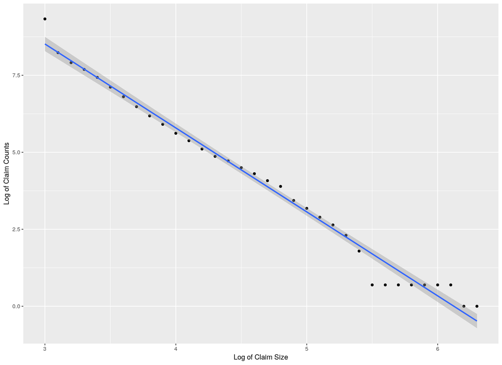

```r
logclaimsize_seq <- seq(0, 7, by = 0.1)

powerlaw_dt <- data.table(
    logsize = logclaimsize_seq
   ,count   = sapply(logclaimsize_seq
                    ,function(iter_m) nrow(claim_dt[claim_amount > 10^iter_m]))
)

power_fit_dt <- powerlaw_dt %>%
    filter(logsize >= 3, count > 0) %>%
    mutate(logcount = log(count))

ggplot(power_fit_dt) +
    geom_point(aes(x = logsize, y = logcount)) +
    geom_smooth(aes(x = logsize, y = logcount), method = 'lm') +
    xlab("Log of Claim Size") +
    ylab("Log of Claim Counts")
```

The log-log plot implies that a power-law is at work here, so now we need to estimate the scaling of this power law which we do by estimating the slope of this line.

```r
powerlaw_lm <- lm(logcount ~ logsize, data = power_fit_dt)

pl_scaling <- -coef(powerlaw_lm)[2]

print(pl_scaling)
```

```
##  logsize
## 2.726067
```

The scaling co-efficient for the power law of large losses is about 2.72.

With this value, the power-law distribution has a finite mean: the mean of this distribution is both well-defined and will converge. We can use simulation and the law of large numbers to estimate its value.

Unfortunately, for distributions with $2 < \alpha < 3$ even-powered moments do not exist, so variance is not defined. This suggests that trying to use the law of large numbers to estimate the variance results in a series that diverges as you increase the sample size. It is worth checking this happens when we try to simulate it.

## 5.2 Estimating Power-Law Losses

With estimates of the scaling, we turn our attention to how to use this information to calculate a compensation charge for these large losses.

Estimating the expected value of a power law distribution is not trivial, from a risk perspective in particular. The occurrence of outsized losses present significant tail risk.

To compensate for assuming the risk of these large losses - losses we explictly choose to model as being entirely random and unpredictable - we need to calculate some kind of charge that we expect will cover their cost. We need to calculate the expectation of these large losses.

To do this, we estimate this expectation by sampling from the distribution, calculating the average value and multiplying this by the probability of a large loss occurring. We then add this amount to every policy price.

```r
N_expect <- 5000000

sample_powerlaw <- poweRlaw::rpldis(N_expect
                                   ,xmin = largeloss_threshold
                                   ,alpha = pl_scaling)

expect_loss <- mean(sample_powerlaw)

print(expect_loss)
```

```
## [1] 11879.25
```

So the expected value of these large losses is just under EUR 12,000 - which is smaller than we expect but the distribution is so skewed that a lot of information is being lost be only stating the mean.

We check this sequence converges as the sample size increases and that the variance diverges.

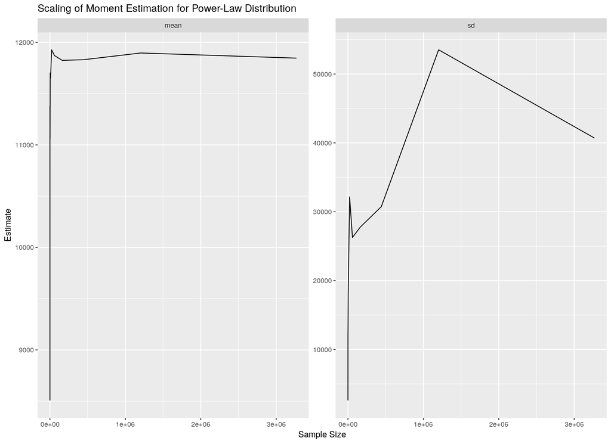

```r
top_exponent <- floor(log(N_expect))

sample_size <- floor(exp(3:top_exponent))


pl_moments <- sapply(sample_size, function(iter_n) {
    iterdata <- sample_powerlaw[1:iter_n]

    c(mean = mean(iterdata), sd = sd(iterdata))
})

plotdata_dt <- data.table(t(pl_moments))
plotdata_dt[, sample_size := sample_size]

ggplot(melt(plotdata_dt, id = 'sample_size')) +
    geom_line(aes(x = sample_size, y = value)) +
    facet_wrap(~variable, scales = 'free') +
    xlab("Sample Size") +
    ylab("Estimate") +
    ggtitle("Scaling of Moment Estimation for Power-Law Distribution")
```

The estimate for the mean value of the distribution is converging on a value while the estimate for the standard deviation is diverging.

Confident in our estimate of the mean, we use this as the estimate for large losses. To calculate the charge, we then need to multiply this by the probability of a large loss occurring to calculate the charge we add to all policies.

```r
n_largeloss <- claim_dt %>%
    filter(claim_amount >= largeloss_threshold) %>%
    nrow

n_policies <- policy_dt %>% nrow

largeloss_charge <- expect_loss * n_largeloss / n_policies

print(largeloss_charge)
```

```
## [1] 18.88977
```

# 6 Calculating a Premium Price

We now have all the pieces we need to price the car insurance we have. We use the Poisson regression to estimate the claim rate for the policy, the Gamma distribution to estimate the size of the claim, multiplying these two values together to get a price due to the premium.

To calculate a quote, we need to charge more for this - partly to cover expenses of running the business: wages, fees, compliance etc, and also to build in a profit margin - an insurance company is not a charity, so we need to charge a price higher than the risk price to earn a profit!

Operating costs for an insurance company tend to go between 20-30% of the premium, so we split the difference, we assume an expense ratio of 25%. We need to increase the premium by 25% to cover expenses. We also build in a profit margin of 10%, so our overall quoted premium will be 1.35 times the risk premium we calculate.

## 6.1 Calculating the Risk Premium

As we require a few components to calculate the risk premium, it will be convenient to wrap the logic into a function that takes policies as an input and returns premium quotes.

We can use the functional aspect of R to wrap this creation of the function as the output of another function: we are writing a function that gives another function as output.

For the moment we will stick with the simple `claim_model_07` model for estimating claim rates: we will introduce methods for dealing with the uncertainty later, but it is better to start with something simple and wrong then lose ourselves in the coding of something more complex. We can worry about standard errors in our coefficients and the impact on pricing later.

```r
create_pricing_function <- function(claimrate_model_glm
                                   ,claimsize_model_glm
                                   ,largeloss_charge
                                   ,quote_ratio) {

    price_function <- function(policydata_dt) {
        claim_rates <- predict(claimrate_model_glm
                              ,newdata = policydata_dt
                              ,type = 'response')

        claim_sizes <- predict(claimsize_model_glm
                              ,newdata = policydata_dt
                              ,type = 'response')

        risk_premium <- claim_rates * claim_sizes

        price_quote <- risk_premium * (1 + quote_ratio)

        return(data.table(price_quote = price_quote, risk_premium = risk_premium))
    }

    return(price_function)
}

premium_quoter <- create_pricing_function(claimrate_model_glm = claim_model_07
                                         ,claimsize_model_glm = size_model_03
                                         ,largeloss_charge    = largeloss_charge
                                         ,quote_ratio         = 0.35)
```

Having built the function to calculate the quotes, we now do so for the training dataset.

```r
trainquotes_dt <- premium_quoter(trainpolicies_dt)

trainpolicies_dt <- trainpolicies_dt %>%
    cbind(trainquotes_dt)

summary(trainpolicies_dt$price_quote)
```

```
##     Min.  1st Qu.   Median     Mean  3rd Qu.     Max.
##   0.1522  20.8877  57.5868  60.7745  91.4169 494.2679
```

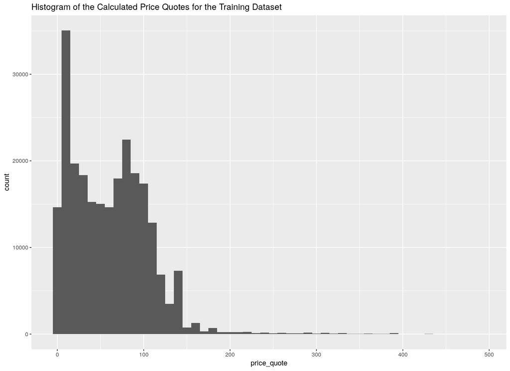

```r
ggplot(trainpolicies_dt) +
    geom_histogram(aes(x = price_quote), binwidth = 10) +
    ggtitle("Histogram of the Calculated Price Quotes for the Training Dataset")
```

Anyone used to paying car insurance is likely to immediately suspect something. The prices quotes seem low, ranging from a few cents up to a few hundred euro. It is possible this is an old dataset so the data is set for a different macroeconomic price level.

It is also possible there is a problem with the model, but the incidence rates from the Poisson model seem reasonable, and the average claim levels we calculated are consisten with the data, so the model is merely reflecting the input.

We note that the use of the non-sampled model did strongly underestimate the incidence rate, but only by a factor of 25-40%. Bumping the premium by this amount will not correct this.

Once quick sanity check is to look at the total premium collected on the training set and compare that to the total claims for those policies. We would hope the claims are lower than the total premium paid - though this is no guarantee.

```r
total_train_premium <- sum(trainpolicies_dt$price_quote)
total_train_claims  <- sum(trainclaim_dt$claim_amount)

print(c(scales::dollar(total_train_premium)
       ,scales::dollar(total_train_claims)
       ,scales::dollar(total_train_premium - total_train_claims)))
```

```
## [1] "$14,893,884" "$10,570,568" "$4,323,316"
```

So from what we have seen, we have taken in about 40% more in premium than we paid out in claims, close to the 35% extra premium we built into our pricing. This is consistent with what we attempted to do at least.

What about the validation set? Does the pricing make a profit for that set of policies. We will check that now.

```r
validquotes_dt <- premium_quoter(validpolicy_dt)

validpolicy_dt <- validpolicy_dt %>%
    cbind(validquotes_dt)

summary(validpolicy_dt$price_quote)
```

```
##     Min.  1st Qu.   Median     Mean  3rd Qu.     Max.
##   0.1522  20.9407  57.5425  60.8951  91.5006 428.2354
```

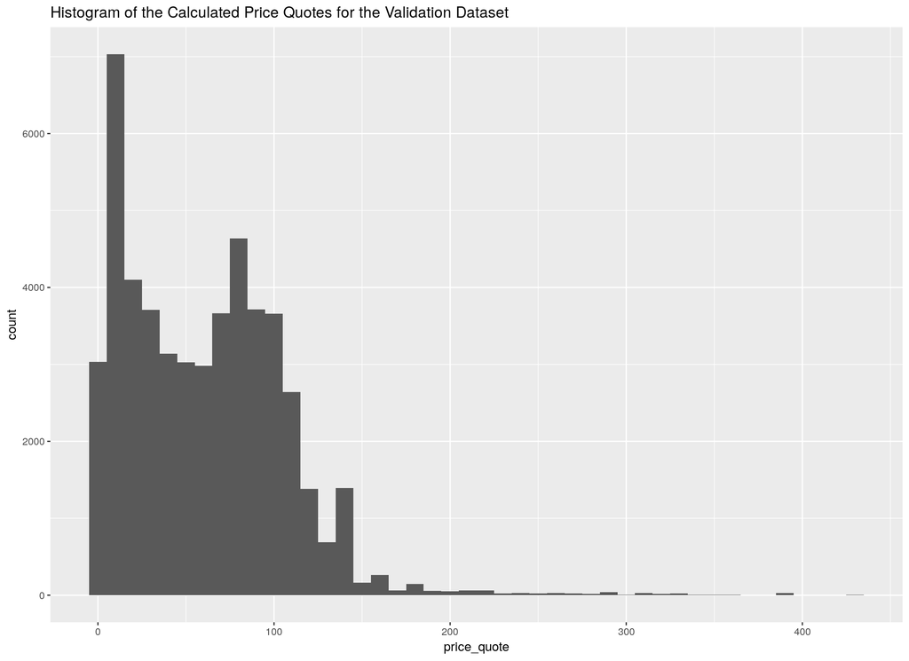

```r
ggplot(validpolicy_dt) +
    geom_histogram(aes(x = price_quote), binwidth = 10) +
    ggtitle("Histogram of the Calculated Price Quotes for the Validation Dataset")
```

```r
total_valid_premium <- sum(validpolicy_dt$price_quote)
total_valid_claims  <- sum(validclaim_dt$claim_amount)

print(c(scales::dollar(total_valid_premium)
       ,scales::dollar(total_valid_claims)
       ,scales::dollar(total_valid_premium - total_valid_claims)))
```

```
## [1] "$3,044,754" "$2,097,229" "$947,525"
```

The validation set has a total premium of about 45% of the premium collected - again matching what we would expect.

We have an initial pricing model, and have performed some very simple heuristic checks to ensure that we have priced it appropriately for the risk being assumed. Checking this more thoroughly is the next step we need to take.

# 7 Write Data

We perform the model checks and validation in another document, so need to save our work. We also save our train/validation/test splits.

```r
### First save the data split
write.csv(trainpolicies_dt, file = 'data/train_data.csv', row.names = FALSE)
write.csv(validpolicy_dt,   file = 'data/valid_data.csv', row.names = FALSE)
write.csv(testpolicies_dt,  file = 'data/test_data.csv',  row.names = FALSE)

write_feather(trainpolicies_dt, path = 'data/train_data.feather')
write_feather(validpolicy_dt,   path = 'data/valid_data.feather')
write_feather(testpolicies_dt,  path = 'data/test_data.feather')


### Save the models
saveRDS(claim_model_07, file = 'data/claim_model.rds',    compress = 'xz')
saveRDS(size_model_03,  file = 'data/size_model.rds',     compress = 'xz')
saveRDS(premium_quoter, file = 'data/premium_quoter.rds', compress = 'xz')
```